# 備忘録_from2025_July_14

### 遺伝研でのSignalPインストール

```bash
(base) kosukesano@a001:~/tools/pyenv_env$ mamba create -n SignalP python=3.6

Looking for: ['python=3.6']

conda-forge/noarch                                  22.6MB @  17.5MB/s  1.3s
conda-forge/linux-64                                47.5MB @  30.6MB/s  1.6s
Transaction

  Prefix: /lustre10/home/kosukesano/.pyenv/versions/mambaforge-23.11.0-0/envs/SignalP

  Updating specs:

   - python=3.6
```

```bash
(SignalP) kosukesano@a001:~/tools/for_SignalP$ wget https://services.healthtech.dtu.dk/download/f9b71e53-6aae-4d10-9fac-7f4ebb527187/signalp-6.0h.slow_sequential.tar.gz
--2025-10-03 18:36:24--  https://services.healthtech.dtu.dk/download/f9b71e53-6aae-4d10-9fac-7f4ebb527187/signalp-6.0h.slow_sequential.tar.gz
Resolving services.healthtech.dtu.dk (services.healthtech.dtu.dk)... 130.225.74.201
Connecting to services.healthtech.dtu.dk (services.healthtech.dtu.dk)|130.225.74.201|:443... connected.
HTTP request sent, awaiting response... 200 OK
Length: 9070585521 (8.4G) [application/x-gzip]
Saving to: ‘signalp-6.0h.slow_sequential.tar.gz’

signalp-6.0h.slow_sequential.tar. 100%[==========================================================>]   8.45G  12.8MB/s    in 11m 19s

2025-10-03 18:47:45 (12.7 MB/s) - ‘signalp-6.0h.slow_sequential.tar.gz’ saved [9070585521/9070585521]

(SignalP) kosukesano@a001:~/tools/for_SignalP$
```

圧縮ファイルのくせに8GBもあってダウンロードがクッソ遅い

```bash
(SignalP) kosukesano@a001:~/tools/for_SignalP$ tar -zxvf signalp-6.0h.slow_sequential.tar.gz
signalp6_slow_sequential/
signalp6_slow_sequential/signalp-6-package/
signalp6_slow_sequential/signalp-6-package/pyproject.toml
signalp6_slow_sequential/signalp-6-package/requirements.txt
signalp6_slow_sequential/signalp-6-package/signalp/
signalp6_slow_sequential/signalp-6-package/signalp/__init__.py
signalp6_slow_sequential/signalp-6-package/signalp/__main__.py
signalp6_slow_sequential/signalp-6-package/signalp/model_weights/
signalp6_slow_sequential/signalp-6-package/signalp/model_weights/README.md
signalp6_slow_sequential/signalp-6-package/signalp/conversion_utils/
signalp6_slow_sequential/signalp-6-package/signalp/conversion_utils/__init__.py
signalp6_slow_sequential/signalp-6-package/signalp/conversion_utils/move_checkpoint_to_device.py
signalp6_slow_sequential/signalp-6-package/signalp/conversion_utils/signalp6_convert_models
signalp6_slow_sequential/signalp-6-package/signalp/make_output_files.py
signalp6_slow_sequential/signalp-6-package/signalp/make_sequence_plot.py
signalp6_slow_sequential/signalp-6-package/signalp/predict.py
signalp6_slow_sequential/signalp-6-package/signalp/sequential_model.py
signalp6_slow_sequential/signalp-6-package/signalp/utils.py
signalp6_slow_sequential/signalp-6-package/models/
signalp6_slow_sequential/signalp-6-package/models/README.md
signalp6_slow_sequential/signalp-6-package/models/sequential_models_signalp6/
signalp6_slow_sequential/signalp-6-package/models/sequential_models_signalp6/test_2_val_0.pt
signalp6_slow_sequential/signalp-6-package/models/sequential_models_signalp6/test_1_val_2.pt
signalp6_slow_sequential/signalp-6-package/models/sequential_models_signalp6/averaged_viterbi.pt
signalp6_slow_sequential/signalp-6-package/models/sequential_models_signalp6/test_0_val_2.pt
signalp6_slow_sequential/signalp-6-package/models/sequential_models_signalp6/test_1_val_0.pt
signalp6_slow_sequential/signalp-6-package/models/sequential_models_signalp6/test_2_val_1.pt
signalp6_slow_sequential/signalp-6-package/models/sequential_models_signalp6/test_0_val_1.pt
signalp6_slow_sequential/signalp-6-package/README.md
signalp6_slow_sequential/signalp-6-package/setup.py
(SignalP) kosukesano@a001:~/tools/for_SignalP$ ls
signalp-6.0h.slow_sequential.tar.gz  signalp6_slow_sequential
(SignalP) kosukesano@a001:~/tools/for_SignalP$ ls signalp6_slow_sequential/
signalp-6-package
(SignalP) kosukesano@a001:~/tools/for_SignalP$ ls signalp6_slow_sequential/signalp-6-package/
README.md  models  pyproject.toml  requirements.txt  setup.py  signalp
(SignalP) kosukesano@a001:~/tools/for_SignalP$
```

インストール

```bash
(SignalP) kosukesano@a001:~/tools/for_SignalP$ cd signalp6_slow_sequential/
(SignalP) kosukesano@a001:~/tools/for_SignalP/signalp6_slow_sequential$ pip install signalp-6-package/
Processing ./signalp-6-package
  Installing build dependencies ... done
  Getting requirements to build wheel ... done
  Preparing metadata (pyproject.toml) ... done
Collecting numpy>1.19.2
  Downloading numpy-1.19.5-cp36-cp36m-manylinux2010_x86_64.whl (14.8 MB)
     |████████████████████████████████| 14.8 MB 9.4 MB/s
Collecting matplotlib>3.3.2
  Downloading matplotlib-3.3.4-cp36-cp36m-manylinux1_x86_64.whl (11.5 MB)
     |████████████████████████████████| 11.5 MB 141.1 MB/s
Collecting tqdm>4.46.1
  Downloading tqdm-4.64.1-py2.py3-none-any.whl (78 kB)
     |████████████████████████████████| 78 kB 9.2 MB/s
Collecting torch<2,>1.7.0
  Downloading torch-1.10.2-cp36-cp36m-manylinux1_x86_64.whl (881.9 MB)
     |████████████████████████████████| 881.9 MB 25 kB/s
Collecting python-dateutil>=2.1
  Downloading python_dateutil-2.9.0.post0-py2.py3-none-any.whl (229 kB)
     |████████████████████████████████| 229 kB 151.8 MB/s
Collecting kiwisolver>=1.0.1
  Downloading kiwisolver-1.3.1-cp36-cp36m-manylinux1_x86_64.whl (1.1 MB)
     |████████████████████████████████| 1.1 MB 141.3 MB/s
Collecting cycler>=0.10
  Downloading cycler-0.11.0-py3-none-any.whl (6.4 kB)
Collecting pyparsing!=2.0.4,!=2.1.2,!=2.1.6,>=2.0.3
  Downloading pyparsing-3.1.4-py3-none-any.whl (104 kB)
     |████████████████████████████████| 104 kB 158.9 MB/s
Collecting pillow>=6.2.0
  Downloading Pillow-8.4.0-cp36-cp36m-manylinux_2_17_x86_64.manylinux2014_x86_64.whl (3.1 MB)
     |████████████████████████████████| 3.1 MB 143.3 MB/s
Collecting typing-extensions
  Downloading typing_extensions-4.1.1-py3-none-any.whl (26 kB)
Collecting dataclasses
  Downloading dataclasses-0.8-py3-none-any.whl (19 kB)
Collecting importlib-resources
  Downloading importlib_resources-5.4.0-py3-none-any.whl (28 kB)
Collecting six>=1.5
  Downloading six-1.17.0-py2.py3-none-any.whl (11 kB)
Collecting zipp>=3.1.0
  Downloading zipp-3.6.0-py3-none-any.whl (5.3 kB)
Building wheels for collected packages: signalp6
  Building wheel for signalp6 (pyproject.toml) ... done
  Created wheel for signalp6: filename=signalp6-6.0+h-py3-none-any.whl size=26350 sha256=edbb97efa9268cb2fb9799f06a8f19f28c6b12a94eb18a340b6a70726f4a0fbc
  Stored in directory: /lustre10/home/kosukesano/.cache/pip/wheels/22/10/97/b521f5413cafb2e1d2c1405a9568fe55fc20dfd0b89a8989be
Successfully built signalp6
Installing collected packages: zipp, six, typing-extensions, python-dateutil, pyparsing, pillow, numpy, kiwisolver, importlib-resources, dataclasses, cycler, tqdm, torch, matplotlib, signalp6
Successfully installed cycler-0.11.0 dataclasses-0.8 importlib-resources-5.4.0 kiwisolver-1.3.1 matplotlib-3.3.4 numpy-1.19.5 pillow-8.4.0 pyparsing-3.1.4 python-dateutil-2.9.0.post0 signalp6-6.0+h six-1.17.0 torch-1.10.2 tqdm-4.64.1 typing-extensions-4.1.1 zipp-3.6.0
(SignalP) kosukesano@a001:~/tools/for_SignalP/signalp6_slow_sequential$
```

ひたすら重い

```bash
(SignalP) kosukesano@a001:~/tools/for_SignalP/signalp6_slow_sequential$ pip install "numpy<2"
Requirement already satisfied: numpy<2 in /lustre10/home/kosukesano/.pyenv/versions/mambaforge-23.11.0-0/envs/SignalP/lib/python3.6/site-packages (1.19.5)
(SignalP) kosukesano@a001:~/tools/for_SignalP/signalp6_slow_sequential$
```

```bash
(SignalP) kosukesano@a001:~/tools/for_SignalP/signalp6_slow_sequential$ ls signalp-6-package/models/
README.md  sequential_models_signalp6
(SignalP) kosukesano@a001:~/tools/for_SignalP/signalp6_slow_sequential$ SIGNALP_DIR=$(python3 -c "import signalp; import os; print(os.path.dirname(signalp.__file__))")

(SignalP) kosukesano@a001:~/tools/for_SignalP/signalp6_slow_sequential$
(SignalP) kosukesano@a001:~/tools/for_SignalP/signalp6_slow_sequential$ cp -r signalp-6-package/models/* $SIGNALP_DIR/model_weights/
(SignalP) kosukesano@a001:~/tools/for_SignalP/signalp6_slow_sequential$ signalp6 --help
usage: SignalP 6.0 Signal peptide prediction tool [-h] --fastafile FASTAFILE
                                                  --output_dir OUTPUT_DIR
                                                  [--format [{txt,png,eps,all,none}]]
                                                  [--organism [{eukarya,other,euk}]]
                                                  [--mode [{fast,slow,slow-sequential}]]
                                                  [--bsize BSIZE]
                                                  [--write_procs WRITE_PROCS]
                                                  [--torch_num_threads TORCH_NUM_THREADS]
                                                  [--version] [--skip_resolve]
                                                  [--model_dir MODEL_DIR]

optional arguments:
  -h, --help            show this help message and exit
  --fastafile FASTAFILE, -ff FASTAFILE, -fasta FASTAFILE
                        Amino acid sequences to predict in FASTA format.
                        (default: None)
  --output_dir OUTPUT_DIR, -od OUTPUT_DIR
                        Path at which to save the output files. Will be
                        created if not existing already. (default: None)
  --format [{txt,png,eps,all,none}], -fmt [{txt,png,eps,all,none}], -f [{txt,png,eps,all,none}], -format [{txt,png,eps,all,none}]
                        Type of single-sequence output files to be created.
                        `txt` produces tabular output, `png`, `eps` and `all`
                        additionally produce figures. `none` only creates
                        prediction summary files. (default: txt)
  --organism [{eukarya,other,euk}], -org [{eukarya,other,euk}]
                        The organism group of origin of the sequences.
                        `eukarya`, `euk` limit predictions to Sec/SPI.
                        (default: other)
  --mode [{fast,slow,slow-sequential}], -m [{fast,slow,slow-sequential}]
                        Which prediction model to use. Modes might have to be
                        installed manually. (default: fast)
  --bsize BSIZE, -bs BSIZE, -batch BSIZE
                        Batch size for prediction. Use to adjust performance
                        to your system memory. (default: 10)
  --write_procs WRITE_PROCS, -wp WRITE_PROCS
                        Number of parallel processes used for writing ouput
                        files. Use to adjust performance to your system
                        memory. (default: 8)
  --torch_num_threads TORCH_NUM_THREADS, -tt TORCH_NUM_THREADS
                        Number of threads used by PyTorch for neural network
                        execution. (default: 8)
  --version             show program's version number and exit
  --skip_resolve        Skip resolving conflicts of the model's Viterbi path
                        and marginal probabilities. In general, should not be
                        activated as it might cause inconsistent prediction
                        behaviour. (default: False)
  --model_dir MODEL_DIR, -md MODEL_DIR
                        Path to directory that contains the model files. Use
                        only when not following default installation
                        instructions. (default: /lustre10/home/kosukesano/.pye
                        nv/versions/mambaforge-23.11.0-0/envs/SignalP/lib/pyth
                        on3.6/site-packages/signalp/model_weights)
(SignalP) kosukesano@a001:~/tools/for_SignalP/signalp6_slow_sequential$
```

インストール完了！

### SignalPのテスト実行

```bash
#!/bin/bash
#SBATCH --job-name=SignalP_test
#SBATCH -n 8
#SBATCH --mem-per-cpu=8G
#SBATCH --partition=epyc
#SBATCH --error=/home/kosukesano/tools/for_SignalP/251003/log/%x_%j_%A_%a.err.log
#SBATCH --output=/home/kosukesano/tools/for_SignalP/251003/log/%x_%j_%A_%a.out.log
#SBATCH --time=120:00:00

#########YOUR JOB#############

echo starting at
date

source /home/kosukesano/tools/pyenv_env/SignalP_profile

# SignalP 6.0の実行

signalp6 \
    --fastafile /home/kosukesano/tools/for_SignalP/251003/Smad_1000.fasta \
    --organism eukarya \
    --output_dir /home/kosukesano/tools/for_SignalP/251003/output \
    --format txt \
    --mode slow


echo ending at
date
```

## 1004

### SignalPテスト結果

`prediction_results.txt`に結果が出力されてる

```bash
# ID    Prediction  OTHER   SP(Sec/SPI) CS Position
Smad_g2717.t1   OTHER   1.000000    0.000000
Smad_g3030.t1   OTHER   1.000000    0.000000
Smad_g209.t1    OTHER   1.000000    0.000000
Smad_g9950.t1   OTHER   1.000000    0.000000
Smad_g6736.t1   OTHER   1.000000    0.000000
Smad_g8243.t1   OTHER   1.000000    0.000000
Smad_g9389.t1   OTHER   1.000000    0.000000
Smad_g4890.t1   SP  0.000158    0.999859    CS pos: 22-23. Pr: 0.9832
Smad_g8100.t1   OTHER   1.000000    0.000000
Smad_g5461.t1   OTHER   1.000000    0.000000
Smad_g886.t1    OTHER   1.000000    0.000000
Smad_g7504.t1   OTHER   1.000000    0.000000
```

ちゃんと1000遺伝子分予測できていた。SPとついていればシグナル配列アリ。

### SignalPでマダラゲノムのシグナル配列を予測する

```bash
#!/bin/bash
#SBATCH --job-name=Smad_SignalP
#SBATCH -n 32
#SBATCH --mem-per-cpu=8G
#SBATCH --partition=epyc
#SBATCH --error=/home/kosukesano/tools/for_SignalP/251004/log/%x_%j_%A_%a.err.log
#SBATCH --output=/home/kosukesano/tools/for_SignalP/251004/log/%x_%j_%A_%a.out.log
#SBATCH --time=120:00:00

#########YOUR JOB#############

echo starting at
date

source /home/kosukesano/tools/pyenv_env/SignalP_profile

# SignalP 6.0の実行

signalp6 \
    --fastafile /home/kosukesano/tools/for_SignalP/251004/Smad_iso1.fasta \
    --organism eukarya \
    --output_dir /home/kosukesano/tools/for_SignalP/251004/output \
    --format txt \
    --mode slow \
    --torch_num_threads 32


echo ending at
date
```

以下のスクリプトを実行した。

## 1006

### 重信ゲノムでもCK関連遺伝子を取っておく

```bash
#!/bin/bash
#SBATCH --job-name=blastp
#SBATCH -n 2
#SBATCH --mem-per-cpu=4G
#SBATCH --partition=short
#SBATCH --error=/home/kosukesano/tools/for_RBH/251006/log/%x_%A_%a.err.log
#SBATCH --output=/home/kosukesano/tools/for_RBH/251006/log/%x_%A_%a.out.log
#SBATCH --time=1:00:00

#########YOUR JOB#############

# ====== ジョブ情報 ======
echo "Starting BLASTP job for array index $SLURM_ARRAY_TASK_ID"
date

# ====== パス設定 ======
QUERY_DIR="/home/kosukesano/tools/for_RBH/251006/query"
DB_PATH="/home/kosukesano/tools/for_RBH/251006/Smad_db"
OUT_BASE="/home/kosukesano/tools/for_RBH/251006/output"

# ====== クエリファイルの決定 ======
QUERY_FILE=$(ls ${QUERY_DIR}/e${SLURM_ARRAY_TASK_ID}_query.fasta)

# ====== 出力ディレクトリとファイル設定 ======
RESULT_DIR="${OUT_BASE}/e${SLURM_ARRAY_TASK_ID}_result"
mkdir -p "$RESULT_DIR"

OUTPUT_FILE="${RESULT_DIR}/blastp_result.txt"
HEADER="qseqid sseqid pident length mismatch gapopen qstart qend sstart send evalue bitscore"

# ====== ヘッダーを書き込む ======
echo "$HEADER" > "$OUTPUT_FILE"

# ====== BLASTp 実行 ======
apptainer exec /usr/local/biotools/b/blast:2.9.0--pl526h979a64d_3 blastp \
  -query "$QUERY_FILE" \
  -db "$DB_PATH" \
  -evalue 1e-10 \
  -num_threads 2 \
  -outfmt 6 >> "$OUTPUT_FILE"

echo "Finished processing $QUERY_FILE"
date
```

### アライメント用配列の準備

e5, g2750

```bash
(SignalP) kosukesano@a001:~/tools/for_RBH/251003/e5$ awk '$2=="Smad_g2750.t1"{print}' f_blastp.txt | sort -k3,3nr | head -n 10
tr|A0A087EB67|A0A087EB67_9BIFI  Smad_g2750.t1   24.735  283     176     8       12      259     18      298     1.43e-17        80.1
tr|A0A087VTX4|A0A087VTX4_9BIFI  Smad_g2750.t1   24.199  281     176     8       10      255     20      298     4.47e-18        80.9
tr|A0A087C0H9|A0A087C0H9_9BIFI  Smad_g2750.t1   23.322  283     180     8       6       253     18      298     9.89e-16        74.3
tr|A0A087EEE9|A0A087EEE9_9BIFI  Smad_g2750.t1   23.308  266     161     9       1       230     23      281     1.02e-12        65.5
tr|A0A080N4P5|A0A080N4P5_9BIFI  Smad_g2750.t1   22.648  287     185     7       6       257     14      298     1.05e-15        74.7
(SignalP) kosukesano@a001:~/tools/for_RBH/251003/e5$
```

e5, g8991

```bash
(SignalP) kosukesano@a001:~/tools/for_RBH/251003/e5$ awk '$2=="Smad_g8991.t1"{print}' f_blastp.txt | sort -k3,3nr | head -n 10
tr|A0A086JHB8|A0A086JHB8_TOXGO  Smad_g8991.t1   45.455  264     137     4       80      342     41      298     1.05e-62        220
tr|A0A086JJU5|A0A086JJU5_TOXGO  Smad_g8991.t1   45.455  264     137     4       80      342     41      298     5.28e-63        221
tr|A0A086K9Y0|A0A086K9Y0_TOXGO  Smad_g8991.t1   45.455  264     137     4       80      342     41      298     5.28e-63        221
tr|A0A086LP87|A0A086LP87_TOXGO  Smad_g8991.t1   45.455  264     137     4       80      342     41      298     6.39e-63        220
tr|A0A086PLJ8|A0A086PLJ8_TOXGO  Smad_g8991.t1   45.455  264     137     4       80      342     41      298     5.73e-63        221
tr|A0A086QEA8|A0A086QEA8_TOXGO  Smad_g8991.t1   45.455  264     137     4       80      342     41      298     5.96e-63        221
tr|A0A086K3R9|A0A086K3R9_TOXGO  Smad_g8991.t1   42.671  307     130     5       60      364     41      303     2.85e-73        247
tr|A0A086K5F8|A0A086K5F8_TOXGO  Smad_g8991.t1   42.671  307     130     5       60      364     41      303     3.19e-73        247
tr|A0A086KVC5|A0A086KVC5_TOXGO  Smad_g8991.t1   42.671  307     130     5       60      364     41      303     1.82e-74        246
tr|A0A086LSQ4|A0A086LSQ4_TOXGO  Smad_g8991.t1   42.671  307     130     5       60      364     41      303     9.64e-72        248
(SignalP) kosukesano@a001:~/tools/for_RBH/251003/e5$
```

```bash
kosukesano@a001:~/tools/for_RBH/251003/e5$ python getupgene.py
Best hit found:
 qseqid: tr|A0A086K9Y0|A0A086K9Y0_TOXGO
 sseqid: Smad_g8991.t1
Sequences saved to /home/kosukesano/tools/for_RBH/251003/e5/g8991.fasta
kosukesano@a001:~/tools/for_RBH/251003/e5$ less g8991.fasta
kosukesano@a001:~/tools/for_RBH/251003/e5$ python getupgene.py
Best hit found:
 qseqid: tr|A0A087EB67|A0A087EB67_9BIFI
 sseqid: Smad_g2750.t1
Sequences saved to /home/kosukesano/tools/for_RBH/251003/e5/g2750.fasta
kosukesano@a001:~/tools/for_RBH/251003/e5$ less g2750.fasta
kosukesano@a001:~/tools/for_RBH/251003/e5$
```

e8, Smad_g405.t1

```bash
(SignalP) kosukesano@a001:~/tools/for_RBH/251003/e8$ awk '$2=="Smad_g405.t1"{print}' f_blastp.txt | sort -k3,3nr | head -n 10
tr|A0A0B5HXG7|A0A0B5HXG7_ARCG3  Smad_g405.t1    49.573  234     111     2       13      239     17      250     3.51e-78        236
tr|A0A0B1U7P0|A0A0B1U7P0_9BACT  Smad_g405.t1    47.718  241     122     2       10      247     14      253     2.08e-75        229
tr|A0A068WL99|A0A068WL99_ECHGR  Smad_g405.t1    45.455  264     129     1       14      277     14      262     6.13e-88        262
tr|A0A068Y2N0|A0A068Y2N0_ECHMU  Smad_g405.t1    44.891  274     136     1       14      287     14      272     1.02e-88        265
tr|A0A0A7LAW9|A0A0A7LAW9_9ARCH  Smad_g405.t1    44.348  230     119     3       14      234     17      246     1.80e-65        204
tr|A0A014LI88|A0A014LI88_9ACTN  Smad_g405.t1    44.304  237     129     1       21      257     20      253     4.78e-67        209
tr|A0A060ZMG8|A0A060ZMG8_9ACTN  Smad_g405.t1    44.304  237     129     1       21      257     20      253     8.05e-67        208
tr|A0A0A0NEW7|A0A0A0NEW7_STRRN  Smad_g405.t1    44.304  237     129     1       21      257     20      253     1.61e-66        207
tr|A0A0B5HUE6|A0A0B5HUE6_9ACTN  Smad_g405.t1    44.017  234     128     1       21      254     20      250     3.57e-67        209
tr|A0A085W5V3|A0A085W5V3_9BACT  Smad_g405.t1    43.814  194     102     2       28      215     28      220     3.06e-49        164
(SignalP) kosukesano@a001:~/tools/for_RBH/251003/e8$
```

e8, Smad_g6551.t1

```bash
(SignalP) kosukesano@a001:~/tools/for_RBH/251003/e8$ awk '$2=="Smad_g6551.t1"{print}' f_blastp.txt | sort -k3,3nr | head -n 10
tr|A0A068WL99|A0A068WL99_ECHGR  Smad_g6551.t1   44.322  273     137     1       15      287     14      271     5.55e-80        242
tr|A0A068Y2N0|A0A068Y2N0_ECHMU  Smad_g6551.t1   44.322  273     137     1       15      287     14      271     3.71e-80        243
tr|A0A0B1U7P0|A0A0B1U7P0_9BACT  Smad_g6551.t1   44.215  242     133     1       8       247     11      252     2.68e-65        203
tr|A0A0B5HXG7|A0A0B5HXG7_ARCG3  Smad_g6551.t1   43.460  237     127     2       13      242     16      252     5.39e-65        202
tr|A0A066Z6S2|A0A066Z6S2_9ACTN  Smad_g6551.t1   43.388  242     133     2       28      269     19      256     1.65e-58        187
tr|A0A060ZMG8|A0A060ZMG8_9ACTN  Smad_g6551.t1   42.623  244     134     2       21      264     19      256     1.88e-59        189
tr|A0A0A0NEW7|A0A0A0NEW7_STRRN  Smad_g6551.t1   42.623  244     134     2       21      264     19      256     4.01e-59        188
tr|A0A0A8ENL5|A0A0A8ENL5_9ACTN  Smad_g6551.t1   42.609  230     129     1       17      246     19      245     2.52e-56        181
tr|A0A061J4J1|A0A061J4J1_TRYRA  Smad_g6551.t1   42.308  208     106     3       28      230     20      218     9.35e-48        160
tr|A0A014LI88|A0A014LI88_9ACTN  Smad_g6551.t1   42.213  244     135     2       21      264     19      256     3.27e-59        189
(SignalP) kosukesano@a001:~/tools/for_RBH/251003/e8$
```

```bash
kosukesano@a001:~/tools/for_RBH/251003/e8$ python getupgene.py
Best hit found:
 qseqid: tr|A0A0B5HXG7|A0A0B5HXG7_ARCG3
 sseqid: Smad_g405.t1
Sequences saved to /home/kosukesano/tools/for_RBH/251003/e8/g405.fasta
kosukesano@a001:~/tools/for_RBH/251003/e8$ python getupgene.py
Best hit found:
 qseqid: tr|A0A068Y2N0|A0A068Y2N0_ECHMU
 sseqid: Smad_g6551.t1
Sequences saved to /home/kosukesano/tools/for_RBH/251003/e8/g6551.fasta
kosukesano@a001:~/tools/for_RBH/251003/e8$
```

e9 Smad_g10297.t1

```bash
(SignalP) kosukesano@a001:~/tools/for_RBH/251003/e9$ awk '$2=="Smad_g10297.t1"{print}' f_blastp.txt | sort -k3,3nr | head -n 10
tr|A0A1I8CT87|A0A1I8CT87_9BILA  Smad_g10297.t1  31.217  189     119     5       5       187     53      236     3.68e-12        66.2
(SignalP) kosukesano@a001:~/tools/for_RBH/251003/e9$
```

e9, Smad_g10740.t1

```bash
(SignalP) kosukesano@a001:~/tools/for_RBH/251003/e9$ awk '$2=="Smad_g10740.t1"{print}' f_blastp.txt | sort -k3,3nr | head -n 10
tr|A0A1J1ISW2|A0A1J1ISW2_9DIPT  Smad_g10740.t1  25.637  589     402     22      261     829     285     857     7.72e-42        166
(SignalP) kosukesano@a001:~/tools/for_RBH/251003/e9$
```

e9, Smad_g11418.t1

```bash
(SignalP) kosukesano@a001:~/tools/for_RBH/251003/e9$ awk '$2=="Smad_g11418.t1"{print}' f_blastp.txt | sort -k3,3nr | head -n 10
tr|A0A0C2XAS6|A0A0C2XAS6_AMAMK  Smad_g11418.t1  34.356  163     80      5       285     441     4       145     1.41e-20        88.6
(SignalP) kosukesano@a001:~/tools/for_RBH/251003/e9$
```

e9, Smad_g1876.t1

```bash
(SignalP) kosukesano@a001:~/tools/for_RBH/251003/e9$ awk '$2=="Smad_g1876.t1"{print}' f_blastp.txt | sort -k3,3nr | head -n 10
tr|A0A087T1K2|A0A087T1K2_STEMI  Smad_g1876.t1   66.000  50      16      1       13      61      6       55      1.41e-14        64.7
tr|A0A0T6B793|A0A0T6B793_9SCAR  Smad_g1876.t1   65.441  272     93      1       1       271     1       272     1.19e-131       375
tr|A0A0L0CEB8|A0A0L0CEB8_LUCCU  Smad_g1876.t1   65.318  346     117     2       1       343     1       346     2.58e-175       489
tr|A0A1I8PKS1|A0A1I8PKS1_STOCA  Smad_g1876.t1   64.912  342     119     1       31      371     5       346     1.03e-171       481
tr|A0A1I8PKZ2|A0A1I8PKZ2_STOCA  Smad_g1876.t1   64.740  346     119     2       1       343     1       346     1.02e-171       480
tr|A0A194R5Q8|A0A194R5Q8_PAPMA  Smad_g1876.t1   64.211  95      33      1       14      107     11      105     2.27e-36        131
tr|A0A067RTD0|A0A067RTD0_ZOONE  Smad_g1876.t1   64.095  337     118     2       6       341     11      345     3.94e-168       471
tr|A0A1D6HDK6|A0A1D6HDK6_MAIZE  Smad_g1876.t1   62.857  70      25      1       5       73      8       77      3.12e-22        88.2
tr|A0A1I8MVS8|A0A1I8MVS8_MUSDO  Smad_g1876.t1   62.428  346     127     2       1       343     1       346     2.48e-168       471
tr|A0A0J7KXH2|A0A0J7KXH2_LASNI  Smad_g1876.t1   62.353  340     127     1       5       343     6       345     6.09e-163       457
(SignalP) kosukesano@a001:~/tools/for_RBH/251003/e9$
```

e9, Smad_g1926.t1

```bash
(SignalP) kosukesano@a001:~/tools/for_RBH/251003/e9$ awk '$2=="Smad_g1926.t1"{print}' f_blastp.txt | sort -k3,3nr | head -n 10
tr|A0A1I8CT87|A0A1I8CT87_9BILA  Smad_g1926.t1   34.896  192     119     4       5       196     61      246     9.41e-28        112
(SignalP) kosukesano@a001:~/tools/for_RBH/251003/e9$
```

```bash
kosukesano@a001:~/tools/for_RBH/251003/e9$ python getupgene.py
Best hit found:
 qseqid: tr|A0A1I8CT87|A0A1I8CT87_9BILA
 sseqid: Smad_g10297.t1
Sequences saved to /home/kosukesano/tools/for_RBH/251003/e9/g10297.fasta
kosukesano@a001:~/tools/for_RBH/251003/e9$ python getupgene.py
Best hit found:
 qseqid: tr|A0A1J1ISW2|A0A1J1ISW2_9DIPT
 sseqid: Smad_g10740.t1
Sequences saved to /home/kosukesano/tools/for_RBH/251003/e9/g10740.fasta
kosukesano@a001:~/tools/for_RBH/251003/e9$ python getupgene.py
Best hit found:
 qseqid: tr|A0A0C2XAS6|A0A0C2XAS6_AMAMK
 sseqid: Smad_g11418.t1
Sequences saved to /home/kosukesano/tools/for_RBH/251003/e9/g11418.fasta
kosukesano@a001:~/tools/for_RBH/251003/e9$ python getupgene.py
Best hit found:
 qseqid: tr|A0A087T1K2|A0A087T1K2_STEMI
 sseqid: Smad_g1876.t1
Sequences saved to /home/kosukesano/tools/for_RBH/251003/e9/g1876.fasta
kosukesano@a001:~/tools/for_RBH/251003/e9$ python getupgene.py
Best hit found:
 qseqid: tr|A0A1I8CT87|A0A1I8CT87_9BILA
 sseqid: Smad_g1926.t1
Sequences saved to /home/kosukesano/tools/for_RBH/251003/e9/g1926.fasta
kosukesano@a001:~/tools/for_RBH/251003/e9$
```

e12, Smad_g4172.t1

```bash
(SignalP) kosukesano@a001:~/tools/for_RBH/251003/e12$ awk '$2=="Smad_g4172.t1"{print}' f_blastp.txt | sort -k3,3nr | head -n 10
tr|A0A2G9FY92|A0A2G9FY92_9LAMI  Smad_g4172.t1   35.780  109     66      2       325     433     250     354     2.01e-14        73.9
tr|A0A251SQ45|A0A251SQ45_HELAN  Smad_g4172.t1   32.576  132     65      4       20      149     243     352     5.58e-13        64.7
tr|A0A2G9H0T9|A0A2G9H0T9_9LAMI  Smad_g4172.t1   31.410  156     77      6       275     430     222     347     3.51e-12        67.4
tr|A0A9K3GSL5|A0A9K3GSL5_HELAN  Smad_g4172.t1   27.344  128     83      2       490     617     253     370     4.21e-12        67.4
(SignalP) kosukesano@a001:~/tools/for_RBH/251003/e12$
```

```bash
kosukesano@a001:~/tools/for_RBH/251003/e12$ python getupgene.py
Best hit found:
 qseqid: tr|A0A2G9FY92|A0A2G9FY92_9LAMI
 sseqid: Smad_g4172.t1
Sequences saved to /home/kosukesano/tools/for_RBH/251003/e12/g4172.fasta
kosukesano@a001:~/tools/for_RBH/251003/e12$
```

## 1007

### SignalPの結果

```bash
  12333 Smad_g4059.t1   SP      0.000149        0.999848        CS pos: 21-22. Pr: 0.9818
  12334 Smad_g9492.t1   OTHER   1.000000        0.000000
  12335 Smad_g11767.t1  OTHER   1.000000        0.000000
  12336 Smad_g11090.t1  OTHER   1.000000        0.000000
  12337 Smad_g7464.t1   SP      0.000154        0.999858        CS pos: 16-17. Pr: 0.9866
  12338 Smad_g2174.t1   OTHER   1.000000        0.000000
  12339 Smad_g9883.t1   SP      0.000159        0.999823        CS pos: 18-19. Pr: 0.9814
```

`~/tools/for_SignalP/251004/output/prediction_results.txt`に結果が出力された。シグナル配列を持つ遺伝子は全部で2056個

シロイヌナズナ・アメリカネナシカズラのRBH遺伝子2767個に当ててみたところ、136個がシグナル配列を持っていた。

### アライメント用配列の準備、論文の配列取得

e5  
[NP_001097260.1](https://www.ncbi.nlm.nih.gov/protein/NP_001097260.1?report=fasta)

e8  
[NP_001246569.1](https://www.ncbi.nlm.nih.gov/protein/NP_001246569.1?report=fasta)

e9  
[NP_001287054.1](https://www.ncbi.nlm.nih.gov/protein/NP_001287054.1?report=fasta)

e12  
[AAD04166.1](https://www.ncbi.nlm.nih.gov/protein/AAD04166.1?report=fasta)

### MAFFTを用いたアライメント

`~/tools/for_MAFFT/251007`に`data/`ディレクトリを作成、そこにCKの配列を移した。

```bash
(MPT) kosukesano@a001:~/tools/for_MAFFT/251007$ ls data/
g10297.fasta  g10740.fasta  g11418.fasta  g1876.fasta  g1926.fasta  g2750.fasta  g405.fasta  g4172.fasta  g6551.fasta  g8991.fasta
(MPT) kosukesano@a001:~/tools/for_MAFFT/251007$
```

そこで以下のスクリプトを実行

```bash
#!/bin/bash
#SBATCH --job-name=MAFFT_array
#SBATCH -n 4
#SBATCH --mem-per-cpu=8G
#SBATCH --partition=epyc
#SBATCH --time=72:00:00
#SBATCH --array=1-10
#SBATCH --error=/home/kosukesano/tools/for_MAFFT/251007/log/%x_%A_%a.err.log
#SBATCH --output=/home/kosukesano/tools/for_MAFFT/251007/log/%x_%A_%a.out.log

######### YOUR JOB #############

# 環境設定
source /home/kosukesano/tools/pyenv_env/MPT_profile_250623

echo "Start at:"
date
echo "Running on node: $(hostname)"
echo "SLURM_ARRAY_TASK_ID = ${SLURM_ARRAY_TASK_ID}"

# ===== ファイルリストを定義 =====
FILE_LIST=(
"g10297.fasta"
"g10740.fasta"
"g11418.fasta"
"g1876.fasta"
"g1926.fasta"
"g2750.fasta"
"g405.fasta"
"g4172.fasta"
"g6551.fasta"
"g8991.fasta"
)

# 対応するファイル名を取得
INPUT_FILE=${FILE_LIST[$((SLURM_ARRAY_TASK_ID-1))]}
BASENAME=$(basename "$INPUT_FILE" .fasta)

# ===== パスの指定 =====
INPUT_DIR=/home/kosukesano/tools/for_MAFFT/251007/data
OUTPUT_DIR=/home/kosukesano/tools/for_MAFFT/251007/result

mkdir -p $OUTPUT_DIR
mkdir -p /home/kosukesano/tools/for_MAFFT/251007/log

# ===== MAFFTの実行 =====
echo "Processing file: $INPUT_FILE"

mafft \
  --auto \
  --maxiterate 1000 \
  --localpair \
  ${INPUT_DIR}/${INPUT_FILE} > ${OUTPUT_DIR}/${BASENAME}_maffted.fasta

echo "Finished processing: $INPUT_FILE"
echo "End at:"
date
```

### trimalでアライメント状況を確認

```bash
#!/bin/bash
#SBATCH --job-name=trimal
#SBATCH --cpus-per-task=1
#SBATCH --partition=short
#SBATCH --time=1:00:00
#SBATCH --array=1-10
#SBATCH --error=/home/kosukesano/tools/for_MAFFT/251007/log/%x_%A_%a.err.log
#SBATCH --output=/home/kosukesano/tools/for_MAFFT/251007/log/%x_%A_%a.out.log

######### YOUR JOB #############

# 環境設定
source /home/kosukesano/tools/pyenv_env/MPT_profile_250623

echo "Start at:"
date
echo "Running on node: $(hostname)"
echo "SLURM_ARRAY_TASK_ID = ${SLURM_ARRAY_TASK_ID}"

# ===== ファイルリストを定義 =====
FILE_LIST=(
"g10297_maffted.fasta"
"g10740_maffted.fasta"
"g11418_maffted.fasta"
"g1876_maffted.fasta"
"g1926_maffted.fasta"
"g2750_maffted.fasta"
"g405_maffted.fasta"
"g4172_maffted.fasta"
"g6551_maffted.fasta"
"g8991_maffted.fasta"
)

# 対応するファイル名を取得
INPUT_FILE=${FILE_LIST[$((SLURM_ARRAY_TASK_ID-1))]}
BASENAME=$(basename "$INPUT_FILE" _maffted.fasta)

# ===== パスの指定 =====
INPUT_DIR=/home/kosukesano/tools/for_MAFFT/251007/result
OUTPUT_DIR=/home/kosukesano/tools/for_MAFFT/251007/trimal_result

mkdir -p $OUTPUT_DIR
mkdir -p /home/kosukesano/tools/for_MAFFT/251007/log

# ===== MAFFTの実行 =====
echo "Processing file: $INPUT_FILE"

trimal \
     -in ${INPUT_DIR}/${BASENAME}_maffted.fasta \
    -out ${OUTPUT_DIR}/${BASENAME}_trimed.fna \
    -htmlout ${OUTPUT_DIR}/${BASENAME}_trimed.html \
    -gt 1.0 -cons 60

echo "Finished processing: $INPUT_FILE"
echo "End at:"
date
```

g405  
荒め

g1876  
BLASTのクエリ配列は最初に少しあるだけ、Dmelとのアライメントは良好

g1926  
BLASTクエリ配列に対してSmad配列は前半に、Dmel配列は後半にアライメントされた

g2750  
荒め、全然アライメントされていない

g4172  
中央の一部はそこそこだが、全体的に荒め

g6551  
中央部が特に揃っている

g8991  
中央部にBLASTクエリ配列のみが持つ領域があるが、その周辺は揃っている。後半はSmadとDmelでのみ存在する配列がある。

g10297  
中央部の20塩基ほどが揃っているものの、前半はDmelに無く、後半はSmadに無い。

g10740  
Dmelが全然揃わない。それ以外も荒め

g11418  
全然揃わない

### IAA関連遺伝子の取得

**BMIAO1：IAAld→IAAを行う酵素**  
[こちらの論文](https://academic.oup.com/bbb/article/83/1/129/5955636#supplementary-data)を参考にした。  
アクセッション番号XM_004925903  
タンパク質配列はXM_004925903.5 → XP_004925960.2  
配列データは[ここ](https://www.ncbi.nlm.nih.gov/protein/XP_004925960.2?report=fasta)から取得

**FMO:Trp→IAOxを行う酵素**  
[こちらの論文](https://www.sciencedirect.com/science/article/pii/S0965174821001223?via%3Dihub)を参考にした。「放線菌 ストレプトマイセス・セリカラーA3のフラビン依存性モノオキシゲナーゼ（FMO）は、 TrpをIAOxに変換する（Ozaki et al., 2013）。」  
配列データは[ここ](https://www.ncbi.nlm.nih.gov/protein/CAD55403.1?report=fasta)

**AAS:Trp→IAAldを行う酵素** [FMOと同じ論文](https://www.sciencedirect.com/science/article/pii/S0965174821001223?via%3Dihub)を参考にした。「芳香族アルデヒド合成酵素（AAS）は芳香族アミノ酸脱炭酸酵素 （AADC）ファミリーに属し、 Medicago truncatulaなどの一部の植物でTrpをIAAldに変換することが示されている（Torrens-Spence et al., 2014）。」  
配列データは[ここ](https://www.ncbi.nlm.nih.gov/protein/NP_001324415.1?report=fasta)

`~/tools/for_RBH/251007`にて以下のスクリプトを実行

```bash
#!/bin/bash
#SBATCH --job-name=IAA_blastp
#SBATCH -n 2
#SBATCH --mem-per-cpu=4G
#SBATCH --partition=short
#SBATCH --error=/home/kosukesano/tools/for_RBH/251007/log/%x_%j_%A_%a.err.log
#SBATCH --output=/home/kosukesano/tools/for_RBH/251007/log/%x_%j_%A_%a.out.log
#SBATCH --time=1:00:00

#########YOUR JOB#############


echo starting at
date

#BLASTの標準列名を定義

header="qseqid sseqid pident length mismatch gapopen qstart qend sstart send evalue bitscore"

#出力ファイルの定義

output_file="f_blastp.txt"

#列名を出力ファイルに書き込む

echo "$header" > $output_file

#BLASTpを実行し、結果を追加する

apptainer exec /usr/local/biotools/b/blast:2.9.0--pl526h979a64d_3 blastp \
-query /home/kosukesano/tools/for_RBH/251007/IAA_query.fasta \
-db /home/kosukesano/tools/for_RBH/251003/Smad_db \
-evalue 1e-10 \
-num_threads 2 \
-outfmt 6 >> $output_file

echo ending at
date
```

結果はこう

```bash
qseqid sseqid pident length mismatch gapopen qstart qend sstart send evalue bitscore
XP_004925960.2  Smad_g8769.t1   40.659  1274    704     23      1       1258    4       1241    0.0     896
XP_004925960.2  Smad_g6191.t1   40.412  1262    714     19      2       1248    7       1245    0.0     892
XP_004925960.2  Smad_g6190.t1   40.523  1261    704     21      2       1243    7       1240    0.0     892
XP_004925960.2  Smad_g1760.t1   38.911  1267    734     28      2       1242    5       1257    0.0     841
XP_004925960.2  Smad_g1133.t1   28.488  1362    814     31      18      1247    31      1364    1.41e-153       496
XP_004925960.2  Smad_g1132.t1   29.911  1354    809     34      6       1252    16      1336    6.75e-149       483
CAD55403.1      Smad_g9019.t1   22.222  351     190     9       21      358     22      302     1.29e-25        106
CAD55403.1      Smad_g9030.t2   33.121  157     101     4       51      206     61      214     4.20e-20        90.9
CAD55403.1      Smad_g9030.t2   31.532  111     70      4       287     393     229     337     2.37e-13        70.1
NP_001324415.1  Smad_g7225.t1   43.505  485     226     7       12      461     1       472     3.27e-128       380
NP_001324415.1  Smad_g10252.t1  41.667  492     231     9       12      461     1       478     6.55e-125       374
NP_001324415.1  Smad_g7222.t1   43.532  487     224     7       12      461     1       473     7.18e-125       370
NP_001324415.1  Smad_g34.t1     38.446  489     250     8       12      463     1       475     3.33e-112       344
NP_001324415.1  Smad_g7224.t1   32.988  482     278     8       12      461     1       469     5.81e-96        296
NP_001324415.1  Smad_g8849.t1   25.130  386     250     6       40      394     85      462     1.05e-30        123
NP_001324415.1  Smad_g8983.t3   23.165  436     287     10      10      408     92      516     1.40e-28        117
```

## 1008

### IAA関連遺伝子のCDS

BMIAO1：IAAld→IAAを行う酵素、XM_004925903.5  
[ここ](https://www.ncbi.nlm.nih.gov/nuccore/XM_004925903.5?report=fasta)

**FMO:Trp→IAOxを行う酵素**

```bash
CDS complement(1..1299) /gene="SCO7468" /gene_synonym="SCBAC14E8.08c" /gene_synonym="SCBAC17A6.01c" /note="SCBAC17A6.01c, possible flavin-containing monooxygenase, len: >327aa: similar to many eg. TR:Q9S204 (EMBL:AL109747) putative flavin-containing monooxygenase SCJ21.03 from Streptomyces coelicolor (458 aa) fasta scores; opt: 909, Z-score: 1021.7, 45.399% identity (45.679% ungapped) in 326 aa overlap and SW:P31513 (FMO3_HUMAN) hepatic flavin-containing monooxygenase FMO3 (defects in which cause fish-odour syndrome) (531 aa) fasta scores; opt: 661, Z-score: 743.2, 34.024% identity (35.826% ungapped) in 338 aa overlap. Contains Pfam match to entry PF00743 FMO-like, Flavin-binding monooxygenase-like.; SCBAC14E8.08c, possible monooxigenase (fragment), len: >140 aa; similar to C-terminal region of SW:FMO5_RABIT (EMBL:L08449) Oryctolagus cuniculus dimethylaniline monooxygenase [N-oxide forming] 5 (EC 1.14.13.8) Fmo5, 532 aa; fasta scores: opt: 259 Z-score: 319.3 bits: 66.9 E(): 3.3e-10; 32.353% identity in 136 aa overlap" /codon_start=1 /transl_table=11 /product="putative flavin-binding monooxygenase" /protein_id="CAD55403.1" /db_xref="GOA:Q8CJJ9" /db_xref="InterPro:IPR000960" /db_xref="InterPro:IPR020946" /db_xref="UniProtKB/TrEMBL:Q8CJJ9"
```

GenBank: AL939131.1、領域: complement(218867..220165)、CDS長: 1299 bpのところにFMOのCDSはある。

これを取得する。以下のスクリプトを実行

```bash
from Bio import Entrez, SeqIO
from Bio.Seq import Seq

# --- NCBI設定 ---
Entrez.email = "sano.kosuke.p8@dc.tohoku.ac.jp"  # ← ご自身のメールアドレスを入力
accession = "AL939131.1"
start = 218867
end = 220165
gene_name = "SCO7468"

# --- GenBankデータを取得 ---
handle = Entrez.efetch(db="nuccore", id=accession, rettype="gb", retmode="text")
record = SeqIO.read(handle, "genbank")
handle.close()

# --- 指定領域を切り出して reverse complement ---
seq_region = record.seq[start-1:end]       # Pythonは0-based
cds_seq = seq_region.reverse_complement()   # complement() + reverse()

# --- FASTA形式で出力 ---
fasta_header = f">{gene_name} {accession}:{start}-{end} complement strand"
print(f"{fasta_header}\n{cds_seq}")
```

結果はこう

```bash
kosukesano@a001:~/tools/for_RBH/251007$ python getFMOCDS.py
>SCO7468 AL939131.1:218867-220165 complement strand
GTGCGTGTGTGTGTGATCGGTGCAGGCCTGTCGGGGCTGGCGATGGGCCATGCCCTGAAG…
kosukesano@a001:~/tools/for_RBH/251007$
```

**AAS:Trp→IAAldを行う酵素** [ここ](https://www.ncbi.nlm.nih.gov/nuccore/NM_001335676.1?report=fasta)から取得

### カイコのゲノムからアイソフォームを抜く

```bash
kosukesano@a001:~/tools/for_RBH/251008/B_mori$ ls
Bombyx_mori.zip  README.md  md5sum.txt  ncbi_dataset
kosukesano@a001:~/tools/for_RBH/251008/B_mori$ ls ncbi_dataset/data/GC
GCA_030269925.2/ GCF_030269925.1/
kosukesano@a001:~/tools/for_RBH/251008/B_mori$ ls ncbi_dataset/data/GC
GCA_030269925.2/ GCF_030269925.1/
kosukesano@a001:~/tools/for_RBH/251008/B_mori$ ls ncbi_dataset/data/GCF_030269925.1/
GCF_030269925.1_ASM3026992v2_genomic.fna  genomic.gff  genomic.gtf  protein.faa  rna.fna
kosukesano@a001:~/tools/for_RBH/251008/B_mori$ ls ncbi_dataset/data/GCA_030269925.2/GCA_030269925.2_ASM3026992v2_genomic.fna
ncbi_dataset/data/GCA_030269925.2/GCA_030269925.2_ASM3026992v2_genomic.fna
kosukesano@a001:~/tools/for_RBH/251008/B_mori$ ls ncbi_dataset/data/GCA_030269925.2/
GCA_030269925.2_ASM3026992v2_genomic.fna
kosukesano@a001:~/tools/for_RBH/251008/B_mori$ ls ncbi_dataset/data/GCF_030269925.1/
GCF_030269925.1_ASM3026992v2_genomic.fna  genomic.gff  genomic.gtf  protein.faa  rna.fna
kosukesano@a001:~/tools/for_RBH/251008/B_mori$ rm -r ncbi_dataset/data/GCA_030269925.2/
kosukesano@a001:~/tools/for_RBH/251008/B_mori$ ls ncbi_dataset/data/GCF_030269925.1/
GCF_030269925.1_ASM3026992v2_genomic.fna  genomic.gff  genomic.gtf  protein.faa  rna.fna
kosukesano@a001:~/tools/for_RBH/251008/B_mori$ source ~/tools/for_isoform_ex/fasp2/bin/activate
(fasp2) kosukesano@a001:~/tools/for_RBH/251008/B_mori$ cd ncbi_dataset/data/GCF_030269925.1/
(fasp2) kosukesano@a001:~/tools/for_RBH/251008/B_mori/ncbi_dataset/data/GCF_030269925.1$ ls
GCF_030269925.1_ASM3026992v2_genomic.fna  genomic.gff  genomic.gtf  protein.faa  rna.fna
(fasp2) kosukesano@a001:~/tools/for_RBH/251008/B_mori/ncbi_dataset/data/GCF_030269925.1$ python3 -m fasp exclude_isoforms_by_length protein.faa Bmor_iso1.faa genomic.gff
(fasp2) kosukesano@a001:~/tools/for_RBH/251008/B_mori/ncbi_dataset/data/GCF_030269925.1$ ls
Bmor_iso1.faa  GCF_030269925.1_ASM3026992v2_genomic.fna  genomic.gff  genomic.gtf  protein.faa  rna.fna
(fasp2) kosukesano@a001:~/tools/for_RBH/251008/B_mori/ncbi_dataset/data/GCF_030269925.1$
```

### カイコのCDS配列のヘッダーをタンパク質配列のものと同じにし、アイソフォームを抜き、ヘッダーを種名と遺伝子IDのみにする。

まず`cds_header.py`を実行

```bash
import re

# 入力ファイル
cds_fasta = "cds_from_genomic.fna"           # CDS（ヌクレオチド）配列
protein_fasta = "protein.faa"   # タンパク質配列
output_fasta = "cds_renamed.fasta"
mapping_file = "cds_protein_mapping.tsv"

# Step 1: タンパク質FASTAから ID→ヘッダー全文 の対応を取得
protein_headers = {}
with open(protein_fasta) as f:
    for line in f:
        if line.startswith(">"):
            # XP_番号を抽出
            match = re.search(r"(XP_\d+\.\d+)", line)
            if match:
                xp_id = match.group(1)
                protein_headers[xp_id] = line.strip()

print(f"タンパク質ID数: {len(protein_headers)}")

# Step 2: CDSファイルを読み込み、対応するXP_ヘッダーを置換
records = []
mapping = []

current_header = None
current_seq = []

def write_record(header, seq):
    if header and seq:
        records.append((header, "".join(seq)))

with open(cds_fasta) as f:
    for line in f:
        line = line.strip()
        if line.startswith(">"):
            # 直前のレコードを保存
            write_record(current_header, current_seq)
            current_header = line
            current_seq = []
        else:
            current_seq.append(line)
# 最後の1件
write_record(current_header, current_seq)

# Step 3: 置換処理
renamed_records = []
for header, seq in records:
    match = re.search(r"(XP_\d+\.\d+)", header)
    if match:
        xp_id = match.group(1)
        if xp_id in protein_headers:
            new_header = protein_headers[xp_id]
            renamed_records.append((new_header, seq))
            mapping.append({
                "XP_ID": xp_id,
                "original_header": header,
                "new_header": new_header
            })
        else:
            # 対応なし → 元のまま出力
            renamed_records.append((header, seq))
            mapping.append({
                "XP_ID": xp_id,
                "original_header": header,
                "new_header": "(no match)"
            })
    else:
        # XP_がない場合もそのまま出力
        renamed_records.append((header, seq))
        mapping.append({
            "XP_ID": "(none)",
            "original_header": header,
            "new_header": "(no XP ID found)"
        })

# Step 4: 出力ファイル作成
with open(output_fasta, "w") as f:
    for h, s in renamed_records:
        f.write(f"{h}\n{s}\n")

# Step 5: 対応表を出力
import pandas as pd
df = pd.DataFrame(mapping)
df.to_csv(mapping_file, sep="\t", index=False)

print(f"✅ 変換完了: {output_fasta}")
print(f"✅ 対応表を出力しました: {mapping_file}")
```

次にアイソフォームを抜く

```bash
(fasp2) kosukesano@a001:~/tools/for_RBH/251008/B_mori/ncbi_dataset/data/GCF_030269925.1$ python3 -m fasp exclude_isoforms_by_length cds_renamed.fasta Bmori_CDS_iso1.faa genomic.gff
(fasp2) kosukesano@a001:~/tools/for_RBH/251008/B_mori/ncbi_dataset/data/GCF_030269925.1$
```

最後に`ch_header.py`を実行

```bash
import re
import pandas as pd

# 入出力ファイル名
input_fasta = "Bmori_CDS_iso1.faa"
output_fasta = "Bmor_CDS_iso1_renamed.faa"
mapping_file = "header_mapping.tsv"

# 対応表を格納するリスト
header_map = []

with open(input_fasta, "r") as infile, open(output_fasta, "w") as outfile:
    for line in infile:
        line = line.strip()
        if line.startswith(">"):
            original_header = line

            # [Genus species] の部分を抽出
            match = re.match(r"^>(\S+).*?\[([A-Za-z]+)\s+([A-Za-z]+)\]", line)
            if match:
                acc = match.group(1)        # XP_004926769.2
                genus = match.group(2)      # Bombyx
                species = match.group(3)    # mori
                short = genus[0] + species[:3]  # Bmor
                new_header = f">{short}_{acc}"
            else:
                # 想定外フォーマットはスキップ（元のヘッダーを維持）
                new_header = original_header

            # 出力FASTAへ書き込み
            outfile.write(new_header + "\n")

            # 対応表に追加（">"を除いた形で記録）
            header_map.append({
                "original_header": original_header.lstrip(">"),
                "new_header": new_header.lstrip(">")
            })
        else:
            outfile.write(line + "\n")

# DataFrame化して保存
df = pd.DataFrame(header_map)
df.to_csv(mapping_file, sep="\t", index=False)

print(f"✅ ヘッダーをリネームして保存しました: {output_fasta}")
print(f"✅ 対応表を出力しました: {mapping_file}")
```

### ショウジョウバエのCDS配列のヘッダーをタンパク質配列のものと同じにし、アイソフォームを抜き、ヘッダーを種名と遺伝子IDのみにする。

```bash
import re

# 入力ファイル
cds_fasta = "cds_from_genomic.fna"           # CDS（ヌクレオチド）配列
protein_fasta = "protein.faa"   # タンパク質配列
output_fasta = "cds_renamed.fasta"
mapping_file = "cds_protein_mapping.tsv"

# Step 1: タンパク質FASTAから ID→ヘッダー全文 の対応を取得
protein_headers = {}
with open(protein_fasta) as f:
    for line in f:
        if line.startswith(">"):
            # XP_番号を抽出
            match = re.search(r"(XP_\d+\.\d+)", line)
            if match:
                xp_id = match.group(1)
                protein_headers[xp_id] = line.strip()

print(f"タンパク質ID数: {len(protein_headers)}")

# Step 2: CDSファイルを読み込み、対応するXP_ヘッダーを置換
records = []
mapping = []

current_header = None
current_seq = []

def write_record(header, seq):
    if header and seq:
        records.append((header, "".join(seq)))

with open(cds_fasta) as f:
    for line in f:
        line = line.strip()
        if line.startswith(">"):
            # 直前のレコードを保存
            write_record(current_header, current_seq)
            current_header = line
            current_seq = []
        else:
            current_seq.append(line)
# 最後の1件
write_record(current_header, current_seq)

# Step 3: 置換処理
renamed_records = []
for header, seq in records:
    match = re.search(r"(XP_\d+\.\d+)", header)
    if match:
        xp_id = match.group(1)
        if xp_id in protein_headers:
            new_header = protein_headers[xp_id]
            renamed_records.append((new_header, seq))
            mapping.append({
                "XP_ID": xp_id,
                "original_header": header,
                "new_header": new_header
            })
        else:
            # 対応なし → 元のまま出力
            renamed_records.append((header, seq))
            mapping.append({
                "XP_ID": xp_id,
                "original_header": header,
                "new_header": "(no match)"
            })
    else:
        # XP_がない場合もそのまま出力
        renamed_records.append((header, seq))
        mapping.append({
            "XP_ID": "(none)",
            "original_header": header,
            "new_header": "(no XP ID found)"
        })

# Step 4: 出力ファイル作成
with open(output_fasta, "w") as f:
    for h, s in renamed_records:
        f.write(f"{h}\n{s}\n")

# Step 5: 対応表を出力
import pandas as pd
df = pd.DataFrame(mapping)
df.to_csv(mapping_file, sep="\t", index=False)

print(f"✅ 変換完了: {output_fasta}")
print(f"✅ 対応表を出力しました: {mapping_file}")
```

### CK、IAAのPAML用OrthoFinderの実行

```bash
(fasp2) kosukesano@a001:~/tools/for_orthofinder/251008$ ls genome/
Agra_iso1.faa  Ccar_iso1.faa  Dpon_iso1.faa  Escr_iso1.faa  Mtri_iso1.faa  Pcer_iso1.faa  Sory_iso1.faa
Bmor_iso1.faa  Dmel_iso1.faa  Ebra_iso1.faa  Ldef_iso1.faa  Orus_iso1.faa  Smad_iso1.faa  Tcas_iso1.faa
(fasp2) kosukesano@a001:~/tools/for_orthofinder/251008$
```

ここで以下のスクリプトを実行

```bash
#!/bin/bash
#SBATCH --job-name=OF3
#SBATCH -n 32
#SBATCH --mem-per-cpu=8G
#SBATCH --partition=epyc
#SBATCH --error=/home/kosukesano/tools/for_orthofinder/251008/log/%x_%j_%A_%a.err.log
#SBATCH --output=/home/kosukesano/tools/for_orthofinder/251008/log/%x_%j_%A_%a.out.log
#SBATCH --time=120:00:00

#########YOUR JOB#############

echo start at
date

source /home/kosukesano/tools/pyenv_env/OrthoFinder3_profile

orthofinder\
        -f /home/kosukesano/tools/for_orthofinder/251008/genome\
        -t 32 \
        -o /home/kosukesano/tools/for_orthofinder/251008/result

echo end at
date
```

## 1009

### 過去のマダラゲノムを元にRBHをとり、ホルモン定量の結果を参照する

ホルモン定量のデータは昔のマダラゲノムデータを使っていた！Jun 27 2024にアップロードした`braker.aa FASTA Protein 16,570`らしい。

これと同じものを探索する

```bash
(fasp2) kosukesano@a001:~/tools/for_braker$ ls Madara/braker/
Augustus      braker.aa         braker.codingseq.zip  braker.log              braker_t1_sequences.aa.zip  genome_header.map  species        what-to-cite.txt
GeneMark-ETP  braker.codingseq  braker.gtf            braker_t1_sequences.aa  errors                      hintsfile.gff      t1tyusyutu.py
(fasp2) kosukesano@a001:~/tools/for_braker$ apptainer exec -e /usr/local/biotools/s/seqkit\:2.5.0--h9ee0642_0 seqkit stat Madara/braker/braker.aa
file                     format  type     num_seqs    sum_len  min_len  avg_len  max_len
Madara/braker/braker.aa  FASTA   Protein    16,570  8,790,187        5    530.5   20,186
(fasp2) kosukesano@a001:~/tools/for_braker$
```

一番最初のアノテーションのやつっぽい。

ヘッダー行を変更する。以下のスクリプト`header_edit.py`を実行

```bash
import os
from Bio import SeqIO

# 入力ディレクトリと出力ディレクトリのパス
input_dir = '../braker/'
output_dir = '251009_header_edit/'

# 出力ディレクトリが存在しない場合は作成
if not os.path.exists(output_dir):
    os.makedirs(output_dir)

# 入力ディレクトリ内のすべての .fasta ファイルを処理
for input_file in os.listdir(input_dir):
    if input_file.endswith('.aa'):
        input_path = os.path.join(input_dir, input_file)
        output_path = os.path.join(output_dir, input_file)

        # 入力ファイルを読み込み、条件に基づいて書き換えた内容を出力ファイルに保存
        with open(output_path, 'w') as outfile:
            for record in SeqIO.parse(input_path, 'fasta'):
                header = record.description
                seq = str(record.seq)

                # ヘッダーが「g」で始まる場合
                if header.startswith("g"):
                    # 新しいヘッダーは「>Smad」 + 「元のヘッダーの番号」
                    number = header.split()[0]  # ヘッダーの最初の番号部分を取得
                    new_header = f">OLD_{number}"

                # ヘッダーが「]」で終わる場合
                elif header.endswith("]"):
                    # ヘッダーの最後の「[]」内の英字を抽出
                    within_brackets = header.split('[')[-1].split(']')[0]
                    first_letter = within_brackets[0]  # 最初の1文字
                    space_after = within_brackets.split()[-1][:3]  # スペース後の3文字

                    # 元のヘッダーから最初の「>」の次の文字から最初の「 」までの部分を取得
                    first_part = header.split()[1][1:]
                    new_header = f">{first_letter}{space_after}_{first_part}"

                else:
                    new_header = f">{header.split()[0]}"

                # 新しいヘッダーと配列を出力ファイルに書き込む
                outfile.write(f"{new_header}\n{seq}\n")

        print(f"{output_path} に保存しました。")
```

```bash
(fasp2) kosukesano@a001:~/tools/for_braker/Madara/braker$ python header_edit.py
251009_header_edit/braker_t1_sequences.aa に保存しました。
251009_header_edit/braker.aa に保存しました。
(fasp2) kosukesano@a001:~/tools/for_braker/Madara/braker$
```

RBHの実行

まずデータを用意

```bash
(fasp2) kosukesano@a001:~/tools/for_RBH/251009/Old_vs_New$ mkdir data
(fasp2) kosukesano@a001:~/tools/for_RBH/251009/Old_vs_New$ cp ~/tools/for_braker/Madara/braker/251009_header_edit/braker.aa data/old_braker.aa
(fasp2) kosukesano@a001:~/tools/for_RBH/251009/Old_vs_New$ ls data/
old_braker.aa
(fasp2) kosukesano@a001:~/tools/for_RBH/251009/Old_vs_New$ cp ~/tools/for_orthofinder/250825/ojiro_madara_sano/Smad_iso1.faa data/
(fasp2) kosukesano@a001:~/tools/for_RBH/251009/Old_vs_New$
(fasp2) kosukesano@a001:~/tools/for_RBH/251009/Old_vs_New$ ls data/
Smad_iso1.faa  old_braker.aa
(fasp2) kosukesano@a001:~/tools/for_RBH/251009/Old_vs_New$
```

**forward**  
旧版マダラゲノムを新版マダラゲノムのデータベースに当てる

```bash
kosukesano@a001:~/tools/for_RBH/251009/Old_vs_New$ mkdir forward
kosukesano@a001:~/tools/for_RBH/251009/Old_vs_New$ cd forward/
kosukesano@a001:~/tools/for_RBH/251009/Old_vs_New/forward$ apptainer exec -e /usr/local/biotools/b/blast:2.9.0--pl526h979a64d_3 makeblastdb -in ../data/Smad_iso1.faa -out New_db -dbtype
prot -hash_index


Building a new DB, current time: 10/09/2025 10:52:48
New DB name:   /home/kosukesano/tools/for_RBH/251009/Old_vs_New/forward/New_db
New DB title:  ../data/Smad_iso1.faa
Sequence type: Protein
Keep MBits: T
Maximum file size: 1000000000B
Adding sequences from FASTA; added 12337 sequences in 0.291901 seconds.
kosukesano@a001:~/tools/for_RBH/251009/Old_vs_New/forward$ ls
New_db.phd  New_db.phi  New_db.phr  New_db.pin  New_db.pog  New_db.psd  New_db.psi  New_db.psq
kosukesano@a001:~/tools/for_RBH/251009/Old_vs_New/forward$
```

以下のスクリプトを実行する

```bash
#!/bin/bash
#SBATCH --job-name=F_blastp
#SBATCH -n 8
#SBATCH --mem-per-cpu=8G
#SBATCH --partition=epyc
#SBATCH --error=/home/kosukesano/tools/for_RBH/251009/Old_vs_New/forward/log/%x_%j_%A_%a.err.log
#SBATCH --output=/home/kosukesano/tools/for_RBH/251009/Old_vs_New/forward/log/%x_%j_%A_%a.out.log
#SBATCH --time=120:00:00

#########YOUR JOB#############


echo starting at
date

#BLASTの標準列名を定義

header="qseqid sseqid pident length mismatch gapopen qstart qend sstart send evalue bitscore"

#出力ファイルの定義

output_file="f_blastp.txt"

#列名を出力ファイルに書き込む

echo "$header" > $output_file

#BLASTpを実行し、結果を追加する

apptainer exec /usr/local/biotools/b/blast:2.9.0--pl526h979a64d_3 blastp \
-query /home/kosukesano/tools/for_RBH/251009/Old_vs_New/data/old_braker.aa \
-db /home/kosukesano/tools/for_RBH/251009/Old_vs_New/forward/Smad_db \
-evalue 1e-04 \
-num_threads 8 \
-outfmt 6 >> $output_file

echo ending at
date
```

**reverse**  
新版マダラゲノムを旧版マダラゲノムデータベースに当てる

```bash
kosukesano@a001:~/tools/for_RBH/251009/Old_vs_New/reverse$ apptainer exec -e /usr/local/biotools/b/blast:2.9.0--pl526h979a64d_3 makeblastdb -in ../data/old_braker.aa -out Old_db -dbtype
prot -hash_index


Building a new DB, current time: 10/09/2025 10:59:39
New DB name:   /home/kosukesano/tools/for_RBH/251009/Old_vs_New/reverse/Old_db
New DB title:  ../data/old_braker.aa
Sequence type: Protein
Keep MBits: T
Maximum file size: 1000000000B
Adding sequences from FASTA; added 16570 sequences in 0.389032 seconds.
kosukesano@a001:~/tools/for_RBH/251009/Old_vs_New/reverse$ ls
Old_db.phd  Old_db.phi  Old_db.phr  Old_db.pin  Old_db.pog  Old_db.psd  Old_db.psi  Old_db.psq
kosukesano@a001:~/tools/for_RBH/251009/Old_vs_New/reverse$
```

以下のスクリプトを実行する

```bash
#!/bin/bash
#SBATCH --job-name=R_blastp
#SBATCH -n 8
#SBATCH --mem-per-cpu=8G
#SBATCH --partition=epyc
#SBATCH --error=/home/kosukesano/tools/for_RBH/251009/Old_vs_New/reverse/log/%x_%j_%A_%a.err.log
#SBATCH --output=/home/kosukesano/tools/for_RBH/251009/Old_vs_New/reverse/log/%x_%j_%A_%a.out.log
#SBATCH --time=120:00:00

#########YOUR JOB#############


echo starting at
date

#BLASTの標準列名を定義

header="qseqid sseqid pident length mismatch gapopen qstart qend sstart send evalue bitscore"

#出力ファイルの定義

output_file="r_blastp.txt"

#列名を出力ファイルに書き込む

echo "$header" > $output_file

#BLASTpを実行し、結果を追加する

apptainer exec /usr/local/biotools/b/blast:2.9.0--pl526h979a64d_3 blastp \
-query /home/kosukesano/tools/for_RBH/251009/Old_vs_New/data/Smad_iso1.faa \
-db /home/kosukesano/tools/for_RBH/251009/Old_vs_New/reverse/Old_db \
-evalue 1e-04 \
-num_threads 8 \
-outfmt 6 >> $output_file

echo ending at
date
```

結果はこんな感じ

```bash
### /home/kosukesano/tools/for_RBH/251009/Old_vs_New/strict_reciprocal_best_hits.txt

qseqid_fwd  sseqid_fwd  pident_fwd  length_fwd  mismatch_fwd    gapopen_fwd qstart_fwd  qend_fwd    sstart_fwd  send_fwd    evalue_fwd  bitscore_fwd    qseqid_rev  sseqid_rev  pident_rev  length_rev  mismatch_rev    gapopen_rev qstart_rev  qend_rev    sstart_rev  send_rev    evalue_rev  bitscore_rev
OLD_g1.t2   Smad_g1.t1  100.000 561 0   0   1   561 1   561 0.0 1173    Smad_g1.t1  OLD_g1.t2   100.000 561 0   0   1   561 1   561 0.0 1173
OLD_g10.t3  Smad_g10.t2 99.279  416 0   1   1   413 1   416 0.0 847 Smad_g10.t2 OLD_g10.t3  99.279  416 0   1   1   416 1   413 0.0 847
OLD_g100.t1 Smad_g98.t1 100.000 399 0   0   1   399 1   399 0.0 820 Smad_g98.t1 OLD_g100.t1 100.000 399 0   0   1   399 1   399 0.0 820
```

10192個の遺伝子がRBH

### 植物ホルモン関連オーソログを抽出する

植物ホルモン関連遺伝子が含まれるOGを抽出

```bash
import pandas as pd
import re

# 入力ファイル
plant_file = "plant_hormone.tsv"
orthofile = "../result/Results_Oct08/Orthogroups/Orthogroups.txt"
output_file = "Smad_OG_match.txt"


# ✅ タブ区切りで読む（カンマを含む値も安全）
plant_df = pd.read_csv(plant_file, sep="\t", engine="python")

# Orthogroups.txt を辞書化
og_dict = {}
with open(orthofile, "r") as f:
    for line in f:
        if ":" not in line:
            continue
        og_id, genes_str = line.strip().split(":", 1)
        genes = re.split(r"[\s,]+", genes_str.strip())
        for g in genes:
            if g:
                og_dict[g] = og_id

# Smad_ID をキーにOG_IDを追加
plant_df["OG_ID"] = plant_df["Smad_ID"].map(og_dict)

# 出力
plant_df.to_csv(output_file, sep="\t", index=False)
print(f"✅ 出力完了: {output_file}")
```

結果はこんな感じ

```bash
function_number Smad_ID OG_ID
e9      Smad_g10297.t1  OG0000564
e9      Smad_g10740.t1  OG0001224
e9      Smad_g10783.t1  OG0001217
e12_e13 Smad_g1104.t1   OG0000083
e9      Smad_g1126.t1   OG0001690
e9      Smad_g11418.t1  OG0006125
```

これを元にOrthoFinderの結果を抽出する

```bash
import os
import pandas as pd
import shutil

# === 入力ファイル ===
og_list_file = "Smad_OG_match.txt"  # function_number, Smad_ID, OG_ID が入ったファイル
base_dir = "../result/Results_Oct08"

# === 出力先 ===
output_root = "./extracted_OGs"
os.makedirs(output_root, exist_ok=True)

# 各サブディレクトリを作成
dirs_to_make = [
    "Orthogroup_Sequences",
    "Orthogroups",
    "Orthologues/Orthologues_Smad_iso1"
]
for d in dirs_to_make:
    os.makedirs(os.path.join(output_root, d), exist_ok=True)

# === 1. OG_ID一覧を取得 ===
df = pd.read_csv(og_list_file, sep=r"\s+", engine="python")
og_ids = sorted(set(df["OG_ID"].dropna()))
print(f"対象となるOG数: {len(og_ids)}")

# === 2. Orthogroup_Sequences/ から該当 .fa をコピー ===
seq_src = os.path.join(base_dir, "Orthogroup_Sequences")
seq_dst = os.path.join(output_root, "Orthogroup_Sequences")

for og in og_ids:
    fa_name = f"{og}.fa"
    src_path = os.path.join(seq_src, fa_name)
    dst_path = os.path.join(seq_dst, fa_name)
    if os.path.exists(src_path):
        shutil.copy2(src_path, dst_path)
        print(f"✓ {fa_name} をコピーしました")
    else:
        print(f"⚠ {fa_name} が見つかりませんでした")

# === 3. Orthogroups/Orthogroups.txt, .tsv, GeneCount.tsv から該当行抽出 ===
og_txt = os.path.join(base_dir, "Orthogroups", "Orthogroups.txt")
og_tsv = os.path.join(base_dir, "Orthogroups", "Orthogroups.tsv")
og_gene = os.path.join(base_dir, "Orthogroups", "Orthogroups.GeneCount.tsv")

og_out_dir = os.path.join(output_root, "Orthogroups")

def extract_lines(src_file, og_ids, dst_file):
    if not os.path.exists(src_file):
        print(f"⚠ {src_file} が見つかりません")
        return
    with open(src_file) as f:
        lines = [line for line in f if any(og in line.split(":")[0] for og in og_ids)]
    with open(dst_file, "w") as f:
        f.writelines(lines)
    print(f"✓ {os.path.basename(dst_file)} に {len(lines)} 行を抽出しました")

extract_lines(og_txt, og_ids, os.path.join(og_out_dir, "Orthogroups.txt"))
extract_lines(og_tsv, og_ids, os.path.join(og_out_dir, "Orthogroups.tsv"))
extract_lines(og_gene, og_ids, os.path.join(og_out_dir, "Orthogroups.GeneCount.tsv"))

# === 4. Orthologues/Orthologues_Smad_iso1/ 以下の tsv から該当行抽出 ===
ortho_src_dir = os.path.join(base_dir, "Orthologues", "Orthologues_Smad_iso1")
ortho_dst_dir = os.path.join(output_root, "Orthologues", "Orthologues_Smad_iso1")

for file in os.listdir(ortho_src_dir):
    if not file.endswith(".tsv"):
        continue
    src_path = os.path.join(ortho_src_dir, file)
    dst_path = os.path.join(ortho_dst_dir, file)
    with open(src_path) as f:
        header = f.readline()
        lines = [header] + [line for line in f if any(og in line for og in og_ids)]
    with open(dst_path, "w") as f:
        f.writelines(lines)
    print(f"✓ {file}: {len(lines)-1} 行抽出")

print("\n🎉 すべてのファイル抽出が完了しました！")
print(f"出力先: {os.path.abspath(output_root)}")
```

結果はこう

```bash
kosukesano@a001:~/tools/for_orthofinder/251008/Plant_hormone$ ls extracted_OGs/
Orthogroup_Sequences  Orthogroups  Orthologues
kosukesano@a001:~/tools/for_orthofinder/251008/Plant_hormone$
```

### 植物ホルモン候補遺伝子の偽陽性をアライメントにより検出する

ファイルリストを作成

```bash
kosukesano@a001:~/tools/for_MAFFT/251009$ ls ~/tools/for_orthofinder/251008/Plant_hormone/extracted_OGs/Orthogroup_Sequences/
OG0000083.fa  OG0000525.fa  OG0000731.fa  OG0001217.fa  OG0001641.fa  OG0002758.fa  OG0004782.fa  OG0005106.fa  OG0005610.fa  OG0006917.fa  OG0008134.fa
OG0000199.fa  OG0000564.fa  OG0000754.fa  OG0001224.fa  OG0001690.fa  OG0003401.fa  OG0004940.fa  OG0005398.fa  OG0005714.fa  OG0007314.fa  OG0008662.fa
OG0000317.fa  OG0000676.fa  OG0000772.fa  OG0001229.fa  OG0001845.fa  OG0003958.fa  OG0005076.fa  OG0005509.fa  OG0005782.fa  OG0007518.fa  OG0008740.fa
OG0000365.fa  OG0000714.fa  OG0001020.fa  OG0001541.fa  OG0002361.fa  OG0004696.fa  OG0005084.fa  OG0005586.fa  OG0006125.fa  OG0007937.fa
kosukesano@a001:~/tools/for_MAFFT/251009$ ls ~/tools/for_orthofinder/251008/Plant_hormone/extracted_OGs/Orthogroup_Sequences/ > file_list.txt
kosukesano@a001:~/tools/for_MAFFT/251009$ less file_list.txt
kosukesano@a001:~/tools/for_MAFFT/251009$
```

このファイルを用いて以下のスクリプトを実行

```bash
#!/bin/bash
#SBATCH --job-name=MAFFT_array
#SBATCH -n 4
#SBATCH --mem-per-cpu=8G
#SBATCH --partition=epyc
#SBATCH --time=72:00:00
#SBATCH --array=1-43
#SBATCH --error=/home/kosukesano/tools/for_MAFFT/251009/log/%x_%A_%a.err.log
#SBATCH --output=/home/kosukesano/tools/for_MAFFT/251009/log/%x_%A_%a.out.log

######### YOUR JOB #############

# ===== 環境設定 =====
source /home/kosukesano/tools/pyenv_env/MPT_profile_250623

echo "Start at:"
date
echo "Running on node: $(hostname)"
echo "SLURM_ARRAY_TASK_ID = ${SLURM_ARRAY_TASK_ID}"

# ===== ファイルリストの読み込み =====
FILE_LIST_PATH=/home/kosukesano/tools/for_MAFFT/251009/file_list.txt
INPUT_FILE=$(sed -n "${SLURM_ARRAY_TASK_ID}p" $FILE_LIST_PATH)
BASENAME=$(basename "$INPUT_FILE" .fa)

# ===== ディレクトリ指定 =====
INPUT_DIR=/home/kosukesano/tools/for_orthofinder/251008/Plant_hormone/extracted_OGs/Orthogroup_Sequences
OUTPUT_DIR=/home/kosukesano/tools/for_MAFFT/251009/result
LOG_DIR=/home/kosukesano/tools/for_MAFFT/251009/log

mkdir -p $OUTPUT_DIR $LOG_DIR

# ===== MAFFTの実行 =====
echo "Processing file: $INPUT_FILE"

mafft \
  --auto \
  --maxiterate 1000 \
  --localpair \
  ${INPUT_DIR}/${INPUT_FILE} > ${OUTPUT_DIR}/${BASENAME}_maffted.fasta

# ===== TrimAlの実行 =====
echo "Running TrimAl on: ${BASENAME}_maffted.fasta"

trimal \
  -in ${OUTPUT_DIR}/${BASENAME}_maffted.fasta \
  -out ${OUTPUT_DIR}/${BASENAME}_trimed.fna \
  -htmlout ${OUTPUT_DIR}/${BASENAME}_trimed.html \
  -gt 1.0 -cons 60

echo "Finished processing: $INPUT_FILE"
echo "End at:"
date
```

### 佐野アノテーションと重信アノテーションのRBH取り直し

過去に行ったやつがどれだかわからなくなったので、もういっそのことやり直す。

**forward**  
佐野アノテーションを重信データベースに当てる

```bash
kosukesano@a001:~/tools/for_RBH/251009/Sano_vs_Sigenobu/forward$ apptainer exec -e /usr/local/biotools/b/blast:2.9.0--pl526h979a64d_3 makeblastdb -in ../data/Sigenobu_madara_iso1.faa -ou
t Sigenobu_db -dbtype prot -hash_index


Building a new DB, current time: 10/09/2025 17:39:06
New DB name:   /home/kosukesano/tools/for_RBH/251009/Sano_vs_Sigenobu/forward/Sigenobu_db
New DB title:  ../data/Sigenobu_madara_iso1.faa
Sequence type: Protein
Keep MBits: T
Maximum file size: 1000000000B
Adding sequences from FASTA; added 14815 sequences in 0.332423 seconds.
kosukesano@a001:~/tools/for_RBH/251009/Sano_vs_Sigenobu/forward$ ls
Sigenobu_db.phd  Sigenobu_db.phi  Sigenobu_db.phr  Sigenobu_db.pin  Sigenobu_db.pog  Sigenobu_db.psd  Sigenobu_db.psi  Sigenobu_db.psq
kosukesano@a001:~/tools/for_RBH/251009/Sano_vs_Sigenobu/forward$
```

以下のスクリプトを実行

```bash
#!/bin/bash
#SBATCH --job-name=F_blastp
#SBATCH -n 8
#SBATCH --mem-per-cpu=8G
#SBATCH --partition=epyc
#SBATCH --error=/home/kosukesano/tools/for_RBH/251009/Sano_vs_Sigenobu/forward/log/%x_%j_%A_%a.err.log
#SBATCH --output=/home/kosukesano/tools/for_RBH/251009/Sano_vs_Sigenobu/forward/log/%x_%j_%A_%a.out.log
#SBATCH --time=120:00:00

#########YOUR JOB#############


echo starting at
date

#BLASTの標準列名を定義

header="qseqid sseqid pident length mismatch gapopen qstart qend sstart send evalue bitscore"

#出力ファイルの定義

output_file="f_blastp.txt"

#列名を出力ファイルに書き込む

echo "$header" > $output_file

#BLASTpを実行し、結果を追加する

apptainer exec /usr/local/biotools/b/blast:2.9.0--pl526h979a64d_3 blastp \
-query /home/kosukesano/tools/for_RBH/251009/Sano_vs_Sigenobu/data/Smad_iso1.faa \
-db /home/kosukesano/tools/for_RBH/251009/Sano_vs_Sigenobu/forward/Sigenobu_db \
-evalue 1e-04 \
-num_threads 8 \
-outfmt 6 >> $output_file

echo ending at
date
```

**reverse**  
重信アノテーションを佐野データベースに当てる

```bash
kosukesano@a001:~/tools/for_RBH/251009/Sano_vs_Sigenobu$ mkdir reverse
kosukesano@a001:~/tools/for_RBH/251009/Sano_vs_Sigenobu$ cd reverse/
kosukesano@a001:~/tools/for_RBH/251009/Sano_vs_Sigenobu/reverse$ apptainer exec -e /usr/local/biotools/b/blast:2.9.0--pl526h979a64d_3 makeblastdb -in ../data/Smad_iso1.faa -out Sano_db -
dbtype prot -hash_index


Building a new DB, current time: 10/09/2025 17:44:50
New DB name:   /home/kosukesano/tools/for_RBH/251009/Sano_vs_Sigenobu/reverse/Sano_db
New DB title:  ../data/Smad_iso1.faa
Sequence type: Protein
Keep MBits: T
Maximum file size: 1000000000B
Adding sequences from FASTA; added 12337 sequences in 0.294589 seconds.
kosukesano@a001:~/tools/for_RBH/251009/Sano_vs_Sigenobu/reverse$ ls
Sano_db.phd  Sano_db.phi  Sano_db.phr  Sano_db.pin  Sano_db.pog  Sano_db.psd  Sano_db.psi  Sano_db.psq
kosukesano@a001:~/tools/for_RBH/251009/Sano_vs_Sigenobu/reverse$
```

以下のスクリプトを実行

```bash
#!/bin/bash
#SBATCH --job-name=R_blastp
#SBATCH -n 8
#SBATCH --mem-per-cpu=8G
#SBATCH --partition=epyc
#SBATCH --error=/home/kosukesano/tools/for_RBH/251009/Sano_vs_Sigenobu/reverse/log/%x_%j_%A_%a.err.log
#SBATCH --output=/home/kosukesano/tools/for_RBH/251009/Sano_vs_Sigenobu/reverse/log/%x_%j_%A_%a.out.log
#SBATCH --time=120:00:00

#########YOUR JOB#############


echo starting at
date

#BLASTの標準列名を定義

header="qseqid sseqid pident length mismatch gapopen qstart qend sstart send evalue bitscore"

#出力ファイルの定義

output_file="f_blastp.txt"

#列名を出力ファイルに書き込む

echo "$header" > $output_file

#BLASTpを実行し、結果を追加する

apptainer exec /usr/local/biotools/b/blast:2.9.0--pl526h979a64d_3 blastp \
-query /home/kosukesano/tools/for_RBH/251009/Sano_vs_Sigenobu/data/Sigenobu_madara_iso1.faa \
-db /home/kosukesano/tools/for_RBH/251009/Sano_vs_Sigenobu/reverse/Sano_db \
-evalue 1e-04 \
-num_threads 8 \
-outfmt 6 >> $output_file

echo ending at
date
```

結果

```bash
9871 Smad_g9998.t1   SM1_g11992.t1   100.000 1507    0       0       1       1507    1       1507    0.0     3066    SM1_g11992.t1   Smad_g9998.t1   100.000 1507    0       0         9871         1       1507    1       1507    0.0     3066
   9872 Smad_g9999.t1   SM1_g11993.t2   100.000 958     0       0       1       958     1       958     0.0     1935    SM1_g11993.t2   Smad_g9999.t1   100.000 958     0       0         9872         1       958     1       958     0.0     1935
```

9872遺伝子がRBH

## 1010

### CK遺伝子のうち、成虫or卵巣で高発現している遺伝子の検出

DEGのデータは昔のマダラゲノムのIDを参照していたので、RBHのデータを元にラベリングしなおす。

`/Users/kosukesano/bio/251001_RBH/251010_CK_DEG_True.png`

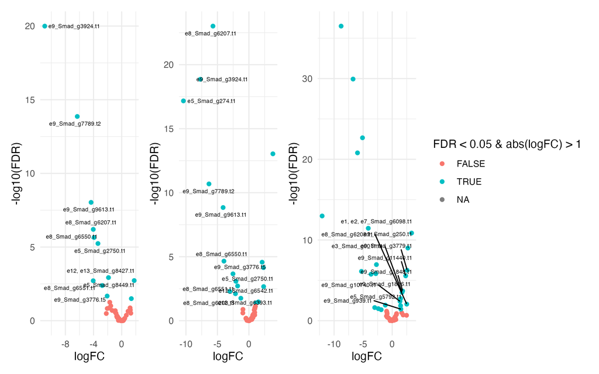

```bash
### r スクリプト
### /Users/kosukesano/bio/251001_RBH/251001_RBH.R


Old_New=readr::read_tsv("/Users/kosukesano/bio/251001_RBH/251010_Old_vs_New.txt")|>
  print()

True_DEG=Old_New|>
  dplyr::mutate(gene_ID=stringr::str_replace(qseqid_fwd, "^OLD_g", "Smad_g"))|>
  dplyr::select(1,2,25)|>
  print()
View(True_DEG)

True_edgeR_1=readr::read_csv("/Users/kosukesano/Desktop/genome_data/241129_Madara_braker/250910_DEG/edgeR_llarva_adult.csv")|>
  dplyr::mutate(gene_ID=stringr::str_replace(gene_ID, "^g", "Smad_g"))|>
  left_join(True_DEG, by="gene_ID")|>
  dplyr::select(2,3,4,5,39,40)|>
  dplyr::rename(Smad_ID=sseqid_fwd)|>
  right_join(CK, by="Smad_ID")|>
  tidyr::unite(label, CK_number, Smad_ID, sep = "_")|>
  print()
View(True_edgeR_1)
p=ggplot(True_edgeR_1, aes(x=logFC, y=-log10(FDR))) +
  geom_point(aes(color = FDR < 0.05 & abs(logFC) > 1)) +
  geom_text_repel(
    aes(label = ifelse(FDR < 0.05 & abs(logFC) > 1& logFC < 0, label, "")),
    size = 2,
    max.overlaps = Inf
  ) +
  guides(color = "none")+
  #theme(aspect.ratio = 2)+
  theme_minimal()
p


True_edgeR_2=readr::read_csv("/Users/kosukesano/Desktop/genome_data/241129_Madara_braker/250910_DEG/edgeR_mlarva_adult.csv")|>
  dplyr::mutate(gene_ID=stringr::str_replace(gene_ID, "^g", "Smad_g"))|>
  left_join(True_DEG, by="gene_ID")|>
  dplyr::select(2,3,4,5,39,40)|>
  dplyr::rename(Smad_ID=sseqid_fwd)|>
  right_join(CK, by="Smad_ID")|>
  tidyr::unite(label, CK_number, Smad_ID, sep = "_")|>
  print()
q=ggplot(True_edgeR_2, aes(x=logFC, y=-log10(FDR))) +
  geom_point(aes(color = FDR < 0.05 & abs(logFC) > 1)) +
  geom_text_repel(
    aes(label = ifelse(FDR < 0.05 & abs(logFC) > 1& logFC < 0, label, "")),
    size = 2,
    max.overlaps = Inf
  ) +
  guides(color = "none")+
  #theme(aspect.ratio = 2)+
  theme_minimal()
q


True_edgeR_3=readr::read_csv("/Users/kosukesano/Desktop/genome_data/241129_Madara_braker/250910_DEG/edgeR_ovary_body.csv")|>
  dplyr::mutate(gene_ID=stringr::str_replace(gene_ID, "^g", "Smad_g"))|>
  left_join(True_DEG, by="gene_ID")|>
  dplyr::select(2,3,4,5,39,40)|>
  dplyr::rename(Smad_ID=sseqid_fwd)|>
  right_join(CK, by="Smad_ID")|>
  tidyr::unite(label, CK_number, Smad_ID, sep = "_")|>
  print()
r=ggplot(True_edgeR_3, aes(x=logFC, y=-log10(FDR))) +
  geom_point(aes(color = FDR < 0.05 & abs(logFC) > 1)) +
  geom_text_repel(
    aes(label = ifelse(FDR < 0.05 & abs(logFC) > 1& logFC > 0, label, "")),
    size = 2,
    max.overlaps = Inf
  ) +
  #guides(color = "none")+
  #theme(aspect.ratio = 2)+
  theme_minimal()
r

s=p+q+r
s
ggsave("/Users/kosukesano/bio/251001_RBH/251010_CK_DEG_True.png", plot = s, width = 8, height = 5, dpi = 300)
```

### 高発現しているCK遺伝子の配列取得

```bash
### /home/kosukesano/tools/for_MAFFT/251010/data/getfasta.py


import pandas as pd
from Bio import SeqIO, Entrez
from pathlib import Path

# === NCBI設定 ===
Entrez.email = "your_email@example.com"  # NCBIアクセス用。適宜変更。

# === 入力ファイル ===
ck_file = "/home/kosukesano/tools/for_MAFFT/251010/data/251010_CK_kouho.tsv"
enzyme_file = "/home/kosukesano/tools/for_MAFFT/251010/data/251010_CK_e1_e17_dataset.tsv"
rbh_base = Path("/home/kosukesano/tools/for_RBH/251003")
output_base = Path("/home/kosukesano/tools/for_MAFFT/251010/data")

# === ファイル読み込み ===
ck_df = pd.read_csv(ck_file, sep="\t")
enzyme_df = pd.read_csv(enzyme_file, sep="\t")

# === 各行処理 ===
for idx, row in ck_df.iterrows():
    ck_label = str(row["CK_label"]).strip()
    target_sseqid = str(row["Smad_ID"]).strip()

    print(f"\n=== Processing {ck_label} / {target_sseqid} ===")

    # 入力ディレクトリ設定
    input_dir = rbh_base / ck_label
    blast_file = input_dir / "f_blastp.txt"
    query_fasta = input_dir / "uniprot_sequences.fasta"
    subject_fasta = rbh_base / "Smad_iso1.faa"

    # 出力ディレクトリ
    output_dir = output_base / ck_label
    output_dir.mkdir(parents=True, exist_ok=True)
    output_fasta = output_dir / f"{target_sseqid.replace('.', '_')}.fasta"

    # BLAST結果を読み込み
    cols = [
        "qseqid", "sseqid", "pident", "length", "mismatch", "gapopen",
        "qstart", "qend", "sstart", "send", "evalue", "bitscore"
    ]
    try:
        df = pd.read_csv(blast_file, sep="\t", names=cols, comment="#")
    except FileNotFoundError:
        print(f"❌ Missing file: {blast_file}")
        continue

    hits = df[df["sseqid"] == target_sseqid]
    if hits.empty:
        print(f"⚠️ No hits found for {target_sseqid}")
        continue

    # pident最大のヒット選択
    best_hit = hits.sort_values("pident", ascending=False).iloc[0]
    qseqid = best_hit["qseqid"]
    sseqid = best_hit["sseqid"]

    print(f"Best hit found:\n  qseqid: {qseqid}\n  sseqid: {sseqid}")

    found_q, found_s, found_ref = False, False, False

    with open(output_fasta, "w") as out_f:
        # qseqidの配列を取得
        for record in SeqIO.parse(query_fasta, "fasta"):
            if record.id.startswith(qseqid):
                SeqIO.write(record, out_f, "fasta")
                found_q = True
                break

        # sseqidの配列を取得
        for record in SeqIO.parse(subject_fasta, "fasta"):
            if record.id == sseqid:
                SeqIO.write(record, out_f, "fasta")
                found_s = True
                break

        # === Enzymeデータセットとの照合 ===
        enzyme_match = enzyme_df[enzyme_df["Enzime_number"] == ck_label]
        if not enzyme_match.empty:
            ncbi_id = enzyme_match.iloc[0]["NCBI_protein_ID"]
            print(f"🧬 Fetching reference protein: {ncbi_id}")

            try:
                # NCBIからFASTAを取得
                handle = Entrez.efetch(db="protein", id=ncbi_id, rettype="fasta", retmode="text")
                ref_seq = handle.read()
                handle.close()

                # 直接FASTAを追記
                out_f.write(ref_seq)
                found_ref = True
            except Exception as e:
                print(f"⚠️ Failed to fetch {ncbi_id}: {e}")

    # === 結果の要約 ===
    if found_q and found_s:
        msg = f"✅ Sequences for {target_sseqid} saved to {output_fasta}"
        if found_ref:
            msg += " (including reference protein)"
    else:
        msg = f"⚠️ Missing sequences for {target_sseqid}"
    print(msg)
```

出力結果はこう

```bash
kosukesano@a001:~/tools/for_MAFFT/251010/data$ python getfasta.py

=== Processing e9 / Smad_g3924.t1 ===
Best hit found:
  qseqid: tr|A0A1I8CT87|A0A1I8CT87_9BILA
  sseqid: Smad_g3924.t1
🧬 Fetching reference protein: NP_001287054.1
✅ Sequences for Smad_g3924.t1 saved to /home/kosukesano/tools/for_MAFFT/251010/data/e9/Smad_g3924_t1.fasta (including reference protein)

=== Processing e9 / Smad_g7789.t2 ===
Best hit found:
  qseqid: tr|A0A0N0U6Z6|A0A0N0U6Z6_9HYME
  sseqid: Smad_g7789.t2
🧬 Fetching reference protein: NP_001287054.1
✅ Sequences for Smad_g7789.t2 saved to /home/kosukesano/tools/for_MAFFT/251010/data/e9/Smad_g7789_t2.fasta (including reference protein)

=== Processing e9 / Smad_g9613.t1 ===
Best hit found:
  qseqid: tr|A0A0M3QWK5|A0A0M3QWK5_DROBS
  sseqid: Smad_g9613.t1
🧬 Fetching reference protein: NP_001287054.1
✅ Sequences for Smad_g9613.t1 saved to /home/kosukesano/tools/for_MAFFT/251010/data/e9/Smad_g9613_t1.fasta (including reference protein)

=== Processing e8 / Smad_g6207.t1 ===
Best hit found:
  qseqid: tr|A0A060ZGV0|A0A060ZGV0_ONCMY
  sseqid: Smad_g6207.t1
🧬 Fetching reference protein: NP_001246569.1
✅ Sequences for Smad_g6207.t1 saved to /home/kosukesano/tools/for_MAFFT/251010/data/e8/Smad_g6207_t1.fasta (including reference protein)

=== Processing e8 / Smad_g6550.t1 ===
Best hit found:
  qseqid: tr|A0A068WL99|A0A068WL99_ECHGR
  sseqid: Smad_g6550.t1
🧬 Fetching reference protein: NP_001246569.1
✅ Sequences for Smad_g6550.t1 saved to /home/kosukesano/tools/for_MAFFT/251010/data/e8/Smad_g6550_t1.fasta (including reference protein)

=== Processing e5 / Smad_g2750.t1 ===
Best hit found:
  qseqid: tr|A0A087EB67|A0A087EB67_9BIFI
  sseqid: Smad_g2750.t1
🧬 Fetching reference protein: NP_001097260.1
✅ Sequences for Smad_g2750.t1 saved to /home/kosukesano/tools/for_MAFFT/251010/data/e5/Smad_g2750_t1.fasta (including reference protein)

=== Processing e12 / Smad_g8427.t1 ===
Best hit found:
  qseqid: tr|A0A251SQ45|A0A251SQ45_HELAN
  sseqid: Smad_g8427.t1
🧬 Fetching reference protein: AAD04166.1
✅ Sequences for Smad_g8427.t1 saved to /home/kosukesano/tools/for_MAFFT/251010/data/e12/Smad_g8427_t1.fasta (including reference protein)

=== Processing e13 / Smad_g8427.t1 ===
Best hit found:
  qseqid: tr|A0ABD1H0I1|A0ABD1H0I1_SALDI
  sseqid: Smad_g8427.t1
🧬 Fetching reference protein: EAZ31595.1
✅ Sequences for Smad_g8427.t1 saved to /home/kosukesano/tools/for_MAFFT/251010/data/e13/Smad_g8427_t1.fasta (including reference protein)

=== Processing e8 / Smad_g6551.t1 ===
Best hit found:
  qseqid: tr|A0A068Y2N0|A0A068Y2N0_ECHMU
  sseqid: Smad_g6551.t1
🧬 Fetching reference protein: NP_001246569.1
✅ Sequences for Smad_g6551.t1 saved to /home/kosukesano/tools/for_MAFFT/251010/data/e8/Smad_g6551_t1.fasta (including reference protein)

=== Processing e9 / Smad_g3776.t5 ===
Best hit found:
  qseqid: tr|A0A0N0U6Z6|A0A0N0U6Z6_9HYME
  sseqid: Smad_g3776.t5
🧬 Fetching reference protein: NP_001287054.1
✅ Sequences for Smad_g3776.t5 saved to /home/kosukesano/tools/for_MAFFT/251010/data/e9/Smad_g3776_t5.fasta (including reference protein)

=== Processing e5 / Smad_g8449.t1 ===
Best hit found:
  qseqid: tr|A0A0A5MPX7|A0A0A5MPX7_AERCA
  sseqid: Smad_g8449.t1
🧬 Fetching reference protein: NP_001097260.1
✅ Sequences for Smad_g8449.t1 saved to /home/kosukesano/tools/for_MAFFT/251010/data/e5/Smad_g8449_t1.fasta (including reference protein)

=== Processing e5 / Smad_g274.t1 ===
Best hit found:
  qseqid: tr|A0A094JHD3|A0A094JHD3_9GAMM
  sseqid: Smad_g274.t1
🧬 Fetching reference protein: NP_001097260.1
✅ Sequences for Smad_g274.t1 saved to /home/kosukesano/tools/for_MAFFT/251010/data/e5/Smad_g274_t1.fasta (including reference protein)

=== Processing e12 / Smad_g6542.t1 ===
Best hit found:
  qseqid: tr|A0A2G9H0T9|A0A2G9H0T9_9LAMI
  sseqid: Smad_g6542.t1
🧬 Fetching reference protein: AAD04166.1
✅ Sequences for Smad_g6542.t1 saved to /home/kosukesano/tools/for_MAFFT/251010/data/e12/Smad_g6542_t1.fasta (including reference protein)

=== Processing e8 / Smad_g6208.t1 ===
Best hit found:
  qseqid: tr|A0A0A1XFM8|A0A0A1XFM8_ZEUCU
  sseqid: Smad_g6208.t1
🧬 Fetching reference protein: NP_001246569.1
✅ Sequences for Smad_g6208.t1 saved to /home/kosukesano/tools/for_MAFFT/251010/data/e8/Smad_g6208_t1.fasta (including reference protein)

=== Processing e12 / Smad_g6393.t1 ===
Best hit found:
  qseqid: tr|A0A251SQ45|A0A251SQ45_HELAN
  sseqid: Smad_g6393.t1
🧬 Fetching reference protein: AAD04166.1
✅ Sequences for Smad_g6393.t1 saved to /home/kosukesano/tools/for_MAFFT/251010/data/e12/Smad_g6393_t1.fasta (including reference protein)

=== Processing e1 / Smad_g6098.t1 ===
❌ Missing file: /home/kosukesano/tools/for_RBH/251003/e1/f_blastp.txt

=== Processing e2 / Smad_g6098.t1 ===
Best hit found:
  qseqid: tr|A0A067R5L3|A0A067R5L3_ZOONE
  sseqid: Smad_g6098.t1
🧬 Fetching reference protein: NP_001189283.1
✅ Sequences for Smad_g6098.t1 saved to /home/kosukesano/tools/for_MAFFT/251010/data/e2/Smad_g6098_t1.fasta (including reference protein)

=== Processing e7 / Smad_g6098.t1 ===
Best hit found:
  qseqid: sp|K3VH30|FCK1_FUSPC
  sseqid: Smad_g6098.t1
🧬 Fetching reference protein: NP_565668.1
✅ Sequences for Smad_g6098.t1 saved to /home/kosukesano/tools/for_MAFFT/251010/data/e7/Smad_g6098_t1.fasta (including reference protein)

=== Processing e9 / Smad_g250.t1 ===
Best hit found:
  qseqid: tr|A0A0P1BJ26|A0A0P1BJ26_9BASI
  sseqid: Smad_g250.t1
🧬 Fetching reference protein: NP_001287054.1
✅ Sequences for Smad_g250.t1 saved to /home/kosukesano/tools/for_MAFFT/251010/data/e9/Smad_g250_t1.fasta (including reference protein)

=== Processing e9 / Smad_g3779.t1 ===
Best hit found:
  qseqid: tr|A0A0P1BJ26|A0A0P1BJ26_9BASI
  sseqid: Smad_g3779.t1
🧬 Fetching reference protein: NP_001287054.1
✅ Sequences for Smad_g3779.t1 saved to /home/kosukesano/tools/for_MAFFT/251010/data/e9/Smad_g3779_t1.fasta (including reference protein)

=== Processing e9 / Smad_g11440.t1 ===
Best hit found:
  qseqid: tr|A0A0N0U6Z6|A0A0N0U6Z6_9HYME
  sseqid: Smad_g11440.t1
🧬 Fetching reference protein: NP_001287054.1
✅ Sequences for Smad_g11440.t1 saved to /home/kosukesano/tools/for_MAFFT/251010/data/e9/Smad_g11440_t1.fasta (including reference protein)

=== Processing e9 / Smad_g1848.t1 ===
Best hit found:
  qseqid: tr|A0A0N0U6Z6|A0A0N0U6Z6_9HYME
  sseqid: Smad_g1848.t1
🧬 Fetching reference protein: NP_001287054.1
✅ Sequences for Smad_g1848.t1 saved to /home/kosukesano/tools/for_MAFFT/251010/data/e9/Smad_g1848_t1.fasta (including reference protein)

=== Processing e3 / Smad_g6011.t1 ===
Best hit found:
  qseqid: tr|A0A0B0EPF7|A0A0B0EPF7_9BACT
  sseqid: Smad_g6011.t1
🧬 Fetching reference protein: NP_415194.1
✅ Sequences for Smad_g6011.t1 saved to /home/kosukesano/tools/for_MAFFT/251010/data/e3/Smad_g6011_t1.fasta (including reference protein)

=== Processing e9 / Smad_g939.t1 ===
Best hit found:
  qseqid: tr|A0A1I7W9W7|A0A1I7W9W7_HETBA
  sseqid: Smad_g939.t1
🧬 Fetching reference protein: NP_001287054.1
✅ Sequences for Smad_g939.t1 saved to /home/kosukesano/tools/for_MAFFT/251010/data/e9/Smad_g939_t1.fasta (including reference protein)

=== Processing e9 / Smad_g1876.t1 ===
Best hit found:
  qseqid: tr|A0A087T1K2|A0A087T1K2_STEMI
  sseqid: Smad_g1876.t1
🧬 Fetching reference protein: NP_001287054.1
✅ Sequences for Smad_g1876.t1 saved to /home/kosukesano/tools/for_MAFFT/251010/data/e9/Smad_g1876_t1.fasta (including reference protein)

=== Processing e5 / Smad_g5792.t1 ===
Best hit found:
  qseqid: tr|A0A080N4P5|A0A080N4P5_9BIFI
  sseqid: Smad_g5792.t1
🧬 Fetching reference protein: NP_001097260.1
✅ Sequences for Smad_g5792.t1 saved to /home/kosukesano/tools/for_MAFFT/251010/data/e5/Smad_g5792_t1.fasta (including reference protein)

=== Processing e9 / Smad_g10740.t1 ===
Best hit found:
  qseqid: tr|A0A1J1ISW2|A0A1J1ISW2_9DIPT
  sseqid: Smad_g10740.t1
🧬 Fetching reference protein: NP_001287054.1
✅ Sequences for Smad_g10740.t1 saved to /home/kosukesano/tools/for_MAFFT/251010/data/e9/Smad_g10740_t1.fasta (including reference protein)
kosukesano@a001:~/tools/for_MAFFT/251010/data$
```

### 高発現しているCK遺伝子のMAFFTとTRIMAL

```bash
#!/bin/bash
#SBATCH --job-name=MAFFT_TRIMAL_CK
#SBATCH -n 4
#SBATCH --mem-per-cpu=8G
#SBATCH --partition=epyc
#SBATCH --time=72:00:00
#SBATCH --array=1-28
#SBATCH --error=/home/kosukesano/tools/for_MAFFT/251010/log/%x_%A_%a.err.log
#SBATCH --output=/home/kosukesano/tools/for_MAFFT/251010/log/%x_%A_%a.out.log

# ===== 環境設定 =====
source /home/kosukesano/tools/pyenv_env/MPT_profile_250623

echo "Start at:"
date
echo "Running on node: $(hostname)"
echo "SLURM_ARRAY_TASK_ID = ${SLURM_ARRAY_TASK_ID}"

# ===== ファイルリスト読み込み =====
TSV_FILE=/home/kosukesano/tools/for_MAFFT/251010/data/251010_CK_kouho.tsv
DATA_DIR=/home/kosukesano/tools/for_MAFFT/251010/data
OUTPUT_BASE=/home/kosukesano/tools/for_MAFFT/251010/result
LOG_DIR=/home/kosukesano/tools/for_MAFFT/251010/log

mkdir -p $OUTPUT_BASE $LOG_DIR

# ===== タスク番号に対応する行を取得 =====
LINE=$(awk -v n=${SLURM_ARRAY_TASK_ID} 'NR==n+1 {print}' $TSV_FILE)
CK_LABEL=$(echo "$LINE" | cut -f1)
SMAD_ID=$(echo "$LINE" | cut -f2)

if [[ -z "$CK_LABEL" || -z "$SMAD_ID" ]]; then
  echo "Error: Failed to read CK_label or Smad_id for task ${SLURM_ARRAY_TASK_ID}"
  exit 1
fi

# ===== Smad_id内のピリオドやハイフンをアンダースコアに変換 =====
SMAD_ID_FIXED=$(echo "$SMAD_ID" | tr '.-' '_')

INPUT_FILE=${DATA_DIR}/${CK_LABEL}/${SMAD_ID_FIXED}.fasta
OUTPUT_DIR=${OUTPUT_BASE}/${CK_LABEL}
BASENAME=${SMAD_ID_FIXED}

# ===== 出力ディレクトリ作成 =====
mkdir -p $OUTPUT_DIR

# ===== ファイル存在チェック =====
if [[ ! -f "$INPUT_FILE" ]]; then
  echo "Error: File not found: $INPUT_FILE"
  echo "Original Smad_id: $SMAD_ID  →  Converted: $SMAD_ID_FIXED"
  exit 1
fi

echo "Processing ${INPUT_FILE}"
echo "Output directory: ${OUTPUT_DIR}"

# ===== MAFFT 実行 =====
mafft --auto --maxiterate 1000 --localpair \
  "$INPUT_FILE" > ${OUTPUT_DIR}/${BASENAME}_maffted.fasta

# ===== TrimAl 実行 =====
trimal \
  -in ${OUTPUT_DIR}/${BASENAME}_maffted.fasta \
  -out ${OUTPUT_DIR}/${BASENAME}_trimed.fna \
  -htmlout ${OUTPUT_DIR}/${BASENAME}_trimed.html \
  -gt 1.0 -cons 60

echo "Finished processing ${BASENAME}"
date
```

**アライメント結果**

**e1**  
なし

**e2**

```bash
kosukesano@a001:~/tools/for_MAFFT/251010$ ls result/e2
Smad_g6098_t1_maffted.fasta  Smad_g6098_t1_trimed.fna  Smad_g6098_t1_trimed.html
kosukesano@a001:~/tools/for_MAFFT/251010$
```

g6098のみ。アライメントはかなり一致

**e3**

```bash
kosukesano@a001:~/tools/for_MAFFT/251010$ ls result/e3
Smad_g6011_t1_maffted.fasta  Smad_g6011_t1_trimed.fna  Smad_g6011_t1_trimed.html
kosukesano@a001:~/tools/for_MAFFT/251010$
```

g6011のみ。アライメントは中央部後半でそこそこ。

**e5**

```bash
kosukesano@a001:~/tools/for_MAFFT/251010$ ls result/e5
Smad_g274_t1_maffted.fasta  Smad_g274_t1_trimed.html     Smad_g2750_t1_trimed.fna   Smad_g5792_t1_maffted.fasta  Smad_g5792_t1_trimed.html    Smad_g8449_t1_trimed.fna
Smad_g274_t1_trimed.fna     Smad_g2750_t1_maffted.fasta  Smad_g2750_t1_trimed.html  Smad_g5792_t1_trimed.fna     Smad_g8449_t1_maffted.fasta  Smad_g8449_t1_trimed.html
kosukesano@a001:~/tools/for_MAFFT/251010$
```

4つ。g8449がそこそこまともだけど全体的にアライメント精度は低め。 NP_001097260.1が長すぎる。

**e7**

```bash
kosukesano@a001:~/tools/for_MAFFT/251010$ ls result/e7
Smad_g6098_t1_maffted.fasta  Smad_g6098_t1_trimed.fna  Smad_g6098_t1_trimed.html
kosukesano@a001:~/tools/for_MAFFT/251010$
```

1つだけ。アライメント精度は低め。

**e8**

```bash
kosukesano@a001:~/tools/for_MAFFT/251010$ ls result/e8
Smad_g6207_t1_maffted.fasta  Smad_g6207_t1_trimed.html    Smad_g6208_t1_trimed.fna   Smad_g6550_t1_maffted.fasta  Smad_g6550_t1_trimed.html    Smad_g6551_t1_trimed.fna
Smad_g6207_t1_trimed.fna     Smad_g6208_t1_maffted.fasta  Smad_g6208_t1_trimed.html  Smad_g6550_t1_trimed.fna     Smad_g6551_t1_maffted.fasta  Smad_g6551_t1_trimed.html
kosukesano@a001:~/tools/for_MAFFT/251010$
```

4つ。どれもアライメントスコア高い。

**e9**

```bash
kosukesano@a001:~/tools/for_MAFFT/251010$ ls result/e9
Smad_g10740_t1_maffted.fasta  Smad_g1848_t1_maffted.fasta  Smad_g250_t1_maffted.fasta   Smad_g3779_t1_maffted.fasta  Smad_g7789_t2_maffted.fasta  Smad_g9613_t1_maffted.fasta
Smad_g10740_t1_trimed.fna     Smad_g1848_t1_trimed.fna     Smad_g250_t1_trimed.fna      Smad_g3779_t1_trimed.fna     Smad_g7789_t2_trimed.fna     Smad_g9613_t1_trimed.fna
Smad_g10740_t1_trimed.html    Smad_g1848_t1_trimed.html    Smad_g250_t1_trimed.html     Smad_g3779_t1_trimed.html    Smad_g7789_t2_trimed.html    Smad_g9613_t1_trimed.html
Smad_g11440_t1_maffted.fasta  Smad_g1876_t1_maffted.fasta  Smad_g3776_t5_maffted.fasta  Smad_g3924_t1_maffted.fasta  Smad_g939_t1_maffted.fasta
Smad_g11440_t1_trimed.fna     Smad_g1876_t1_trimed.fna     Smad_g3776_t5_trimed.fna     Smad_g3924_t1_trimed.fna     Smad_g939_t1_trimed.fna
Smad_g11440_t1_trimed.html    Smad_g1876_t1_trimed.html    Smad_g3776_t5_trimed.html    Smad_g3924_t1_trimed.html    Smad_g939_t1_trimed.html
kosukesano@a001:~/tools/for_MAFFT/251010$
```

11こ。  
精度悪め  
- 250 - 939 - 3776 - 3779 - 3924 - 7789 - 9613 - 10740 - 11440

精度高め  
- 1848(Uniprotクエリ配列と) - 1876(Uniprotクエリが短いが、3つともかなり一致度が高い)

**e12**

```bash
kosukesano@a001:~/tools/for_MAFFT/251010$ ls result/e12
Smad_g6393_t1_maffted.fasta  Smad_g6393_t1_trimed.html    Smad_g6542_t1_trimed.fna   Smad_g8427_t1_maffted.fasta  Smad_g8427_t1_trimed.html
Smad_g6393_t1_trimed.fna     Smad_g6542_t1_maffted.fasta  Smad_g6542_t1_trimed.html  Smad_g8427_t1_trimed.fna
kosukesano@a001:~/tools/for_MAFFT/251010$
```

3つ。どれも中央後半が一致気味。

**e13**

```bash
kosukesano@a001:~/tools/for_MAFFT/251010$ ls result/e13
Smad_g8427_t1_maffted.fasta  Smad_g8427_t1_trimed.fna  Smad_g8427_t1_trimed.html
kosukesano@a001:~/tools/for_MAFFT/251010$
```

1つ。精度は悪い。